# An Introduction to the ShapeMotifEM Package

Nanjun Chen and Ka-Chun Wong

nanjuchen2-c@my.cityu.edu.hk  
kc.w@cityu.edu.hk

2023-05-20

# 1 Introduction

This R package is design for DNA shape motif discovery with multiple shape feature input. With the input of GRanges file or FASTA format file of ChIP-Seq data, users will be able to carry on DNA shape motif discovery, and visualize the shape motifs.

# 2 Load ShapeMotifEM and Biostrings

```r
# install.packages("ShapeMotifEM_0.0.1.0000.tar.gz", repos = NULL, type = "source")
library(ShapeMotifEM)
library(Biostrings)
```

# 3 Table of contents

## 3.1 Contents overview

The ShapeMotifEM package contains four main parts: 1. Data pre-processing functions, 2. Shape motif discovery functions, 3. Result processing functions, 4. Visualization methods. Additionally, an example dataset is provided for users to replicate the processes described in this document.

## 3.2 Data pre-processing functions

The data pre-processing section includes two functions: 1. `gr_input`, 2. `fasta_input`. These functions read GRanges files or FASTA files, respectively, and process them into DNA shape data. The DNA shape data can then be used as input for the DNA shape motif discovery functions.

## 3.3 Shape motif discovery functions

In this version, we provide 3 algorithms for DNA shape motif discovery: 1. `SMEM`, 2. `SMEM_Gibb`s, 3. `SM_Gibbs`. These functions read the DNA shape data file and perform shape motif discovery. With the generalizability of all three models, DNA shape data that adheres to the data pre-processing rules can also be used as input, and the resulting location array of the shape motifs will be obtained.

## 3.4 Result processing functions

These functions read the location array of DNA shape motifs. By collecting statistics and organizing the results, these functions generate the final motif location results.

Corresponding to the pre-processing method, this section also contains two methods: 1. `gr_motif_merge`, 2. `fasta_motif_merge`. Besides providing the motif shape data, users who use the GRanges form input will obtain the location and genomic coordinates of each motif. Users who use the FASTA form input will obtain the location and motif sequence based on the input FASTA file.

## 3.5 Visualization methods

In this section, users can align and visualize discovered motifs by adjusting different parameters. The `motif_visualizer` function in this section is an interactive function that allows users to adjust alignment parameters in real time and visualize the discovered motifs.

## 3.6 Example data

The package includes a GRanges file of the A549 cell line with MAX transcription factor: `A549_MAX_gr`. This dataset is used to demonstrate the package’s functions and allows users to replicate the processes in practical applications.

# 4 User Instructions

## 4.1 DNA Shape motif discovery with GRanges input

This part is the instructions of carry on DNA shape motif discovery with GRanges file input.

### 4.1.1 Multiple features

#### 4.1.1.1 Get shape data with multiple shape features

Firstly, we load the ChIP-Seq sequencing data of MAX transcription factors obtained from the A549 cell line, which is included in the package, as the input. This GRanges file serves as an illustrative example to demonstrate the usage of the ShapeMotifEM package.

To load the example data, follow the steps below:

```r
example_data = system.file("data", "A549_MAX_gr.RData", package = "ShapeMotifEM")
example_gr_file = load(example_data)
example_gr_file
```

```
## [1] "A549_MAX_gr"
```

Check the input GRanges file:

```r
A549_MAX_gr
```

```
## GRanges object with 9881 ranges and 6 metadata columns:
##          seqnames              ranges strand |        name     score
##             <Rle>           <IRanges>  <Rle> | <character> <numeric>
##      [1]     chr7     4681585-4681910      * |        <NA>      1000
##      [2]    chr19     2783418-2783684      * |        <NA>      1000
##      [3]    chr17   57642676-57642964      * |        <NA>      1000
##      [4]     chr7       915801-916225      * |        <NA>      1000
##      [5]     chr5 179499099-179499372      * |        <NA>      1000
##      ...      ...                 ...    ... .         ...       ...
##   [9877]     chr1   23961443-23961792      * |        <NA>       149
##   [9878]    chr11 126223217-126223566      * |        <NA>       149
##   [9879]    chr16   30825579-30825928      * |        <NA>       149
##   [9880]     chr5   66299645-66299994      * |        <NA>       149
##   [9881]     chr1   93426215-93426564      * |        <NA>       149
##          signalValue    pValue    qValue      peak
##            <numeric> <numeric> <numeric> <numeric>
##      [1]     365.649        -1   3.84042       162
##      [2]     352.777        -1   3.84042       130
##      [3]     351.807        -1   3.84042       143
##      [4]     340.137        -1   3.84042       134
##      [5]     335.835        -1   3.84042       140
##      ...         ...       ...       ...       ...
##   [9877]     23.4344        -1   3.06755       175
##   [9878]     23.4344        -1   3.06760       175
##   [9879]     23.4336        -1   3.06764       175
##   [9880]     23.4327        -1   3.06768       175
##   [9881]     23.4302        -1   3.06773       175
##   -------
##   seqinfo: 298 sequences (2 circular) from hg19 genome
```

Next, function `gr_input` can be used to obtain dna shape data that meets subsequent input requirements. In addition to the input data, `gr_input` function contains the following parameters:

1. `peakLength`: This parameter determines the length of the center peak to be processed.
2. `total_peak_number`: Specifies the total number of peaks for shape motif discovery.
3. `fasta_name`: The `gr_input` function, which utilizes the included `DNAShapeR` package, generates a FASTA file based on the GRanges file. Here, you can provide a name for the FASTA file.
4. `shapeind`: Users can choose to perform shape motif discovery on either multiple shape features or a single shape feature by setting the shape index. The default value is “all”. Additionally, integer from 1 to 5 correspond to the features “MGW,” “HelT,” “ProT,” “Roll,” and “EP,” respectively.
5. `sort_by`: Users can sort the GRanges file according to your preference by setting the `sort_by` parameter. Options for sorting include: “score,” “signalValue,” “pValue,” “qValue,” “peak,” and “none.”
6. `sort_descend`: This parameter allows you to specify whether the peaks should be sorted in ascending or descending order.

```r
gr_input_result = gr_input(
  A549_MAX_gr,
  peakLength = 100,
  total_peak_number = 100,
  fasta_name = "fasta.fa",
  shapeind = "all",
  sort_by = "signalValue",
  sort_descend = TRUE
)
```

```
## [1] "Extracting peaks, please wait..."
## Reading the input sequence......
## Reading the input sequence......
## Reading the input sequence......
## Reading the input sequence......
## Reading the input sequence......
## Reading the input sequence......
## Reading the input sequence......
## Reading the input sequence......
## Reading the input sequence......
## Reading the input sequence......
## Reading the input sequence......
## Reading the input sequence......
## Reading the input sequence......
## Reading the input sequence......
## [1] "the modified gr file and DNA shape data is returned as '$gr_file' and '$dna_shape_data'"
```

User can check the View pre-processed GRanges file results by:

```r
gr_input_result$gr_file
## GRanges object with 100 ranges and 0 metadata columns:
##         seqnames              ranges strand
##            <Rle>           <IRanges>  <Rle>
##     [1]     chr1     6762037-6762136      *
##     [2]     chr1   26758579-26758678      *
##     [3]     chr1   38478121-38478220      *
##     [4]     chr1 154531328-154531427      *
##     [5]     chr2   27440266-27440365      *
##     ...      ...                 ...    ...
##    [96]    chr19   50529259-50529358      *
##    [97]    chr19   55987543-55987642      *
##    [98]    chr19   56015192-56015291      *
##    [99]    chr20       343207-343306      *
##   [100]    chr20     3788889-3788988      *
##   -------
##   seqinfo: 298 sequences (2 circular) from hg19 genome
```

User can also check the obtained DNA shape data:

```r
gr_input_result$dna_shape_data
```

An example of the shape data:

```r
gr_input_result$dna_shape_data[, , 1]
```

```
##        [,1]  [,2]  [,3]  [,4]  [,5]  [,6]  [,7]  [,8]  [,9] [,10] [,11] [,12]
##  [1,]  4.95  4.90  5.02  5.09  5.20  5.51  5.37  5.09  5.41  5.41  4.77  4.97
##  [2,] 34.05 36.05 34.11 33.11 35.72 32.41 33.52 36.24 32.32 36.28 34.19 31.49
##  [3,] -2.56 -5.28 -8.11 -7.38 -4.73 -4.25 -3.73 -3.17 -3.39 -3.39 -2.82 -1.23
##  [4,] -0.92 -2.07 -2.47  4.37 -1.22  2.73 -1.32 -1.58  2.85 -1.94 -2.03 -2.35
##  [5,] -5.44 -5.50 -7.29 -5.25 -4.86 -4.76 -5.10 -5.17 -5.12 -5.12 -5.21 -5.65
##  [6,]  3.43  3.23  3.33  3.46  3.39  3.33  3.33  3.38  3.31  3.40  3.44  3.27
##  [7,]  0.02 -0.20  0.24  0.03  0.00 -0.01  0.10 -0.01  0.00  0.04 -0.10 -0.23
##  [8,] -1.77 -1.40 -1.50 -1.65 -1.55 -1.62 -1.71 -1.56 -1.58 -1.58 -1.85 -1.76
##  [9,]  0.92  0.32 -0.51 -0.30 -0.02 -0.59  0.17  0.12  0.00  0.03 -1.32  1.89
## [10,]  1.90 -1.50  3.23  5.02 -1.59  1.65  0.16  0.28 -0.35  0.35 -0.23 -4.00
## [11,]  0.18  0.34 -0.30  0.64  0.46  0.44  0.28  0.24  0.39  0.39  0.40  0.19
## [12,] -0.28 -0.31  0.10  0.26 -0.27  0.24 -0.26 -0.27  0.25 -0.25  0.30  0.25
## [13,]  0.09 -0.05 -0.01 -0.03  0.00  0.02  0.05  0.07  0.06  0.06  0.02  0.16
## [14,] -0.04 -0.05 -0.02 -0.02 -0.03 -0.03 -0.04 -0.04 -0.03 -0.03 -0.04 -0.03
```

[output cut: 120 more lines]

#### 4.1.1.2 Run ShapeMotifEM (SMEM) algorithm

Next, users can use the DNA shape data generated in the previous step for motif discovery. Here is the example of using the functions SMEM and SMEM_Gibbs.

Function `SMEM` and `SMEM_Gibbs` include same parameters:

1. `DNA_shape_data`: Input DNA shape data convert by function fasta_input, gr_input, or other shape data adheres to the data pre-processing rules.
2. `filename`: Name of the output the .csv results.
3. `peakCount`: The number of peaks to retrieve per batch, default is 20.
4. `motifLength`: The length of shape motif to be discovered, default is 12.
5. `motifCount`: The number of motifs to be discovered for each replicate, default is 2.
6. `replicates`: The number of repetitions for each batch, default is 50.
7. `tolerance`: The tolerance threshold for EM and EM_Gibbs iteration, default is 0.000001.

Note that increasing the number of repetitions leads to improved statistical accuracy, but it also extends the duration of the experiment. Therefore, users are encouraged to find a balance between the two factors based on their specific needs.

```r
dna_shape_data = gr_input_result$dna_shape_data

EM_result = SMEM(
  dna_shape_data,
  filename = "A549_MAX",
  peakCount = 50,
  motifLength = 12,
  motifCount = 2,
  replicates = 50,
  tolerance = 1e-06
)

EM_result
```

```r
dim(EM_result)
```

```
## [1] 100 100
```

The top 10 rows of the result is shown as an example:

```r
EM_result[1:10,]
```

```
##       [,1] [,2] [,3] [,4] [,5] [,6] [,7] [,8] [,9] [,10] [,11] [,12] [,13]
##  [1,]   46   64   29   28   51   43   40   71   70    61    39    56    49
##  [2,]   41    2   29   72   82   15   31   57   30    29    90    14    61
##  [3,]   45   63   28   25   79   42   26   70   12    60    38    55    48
##  [4,]   58    8   35   79   47   10   72   63   36    36    88    52    20
##  [5,]   44    5   33   76   44   18   70   60   79    28    47     7    65
##  [6,]   56    5   62   76   45    8   70   -1   34    28    86    50    18
##  [7,]   69   63   28   25   79   42   32   70   12    60    38    55    62
##  [8,]   53    2   30   73   42    5   67   58   31    30    45    47    15
##  [9,]   56    6   62   76   45    8   70   -1   34    28    47    50    18
## [10,]   41    2   30   73   41   16   32   57   30    21    90    15    62
##       [,14] [,15] [,16] [,17] [,18] [,19] [,20] [,21] [,22] [,23] [,24] [,25]
##  [1,]    51    74    11    39    56    53    18    58    56    20    36     7
##  [2,]    21    46    79    72    46    90    18    12    12    29    27    70
##  [3,]    50    73    41    38    55    52    17    57    55    54    35     6
```

[output cut: 84 more lines]

#### 4.1.1.3 Run ShapeMotifEM (SMEM_Gibbs) algorithm

The algorithm SMEM_Gibbs can be applied in the same manner:

```r
EM_Gibbs_result = SMEM_Gibbs(
  dna_shape_data,
  filename = "A549_MAX",
  peakCount = 50,
  motifLength = 12,
  motifCount = 2,
  replicates = 50,
  tolerance = 1e-06
)

EM_Gibbs_result
```

The generalized Gibbs method that support multiple shape features input can be used as follows:

```r
Gibbs_result = SM_Gibbs(
  dna_shape_data,
  filename = "A549_MAX",
  peakCount = 50,
  motifLength = 12,
  motifCount = 2,
  replicates = 50,
  tolerance = 1e-06
)

Gibbs_result
```

#### 4.1.1.5 Merge results

In the next section, for GRanges file input, the final results of each DNA shape motif can be obtained using function `gr_motif_merge`. The parameter of the function include:

1. `motif_location_array`: The motif location array output by function `SMEM` or `SMEM_Gibbs`.
2. `gr_file`: The GRanges file used to obtian the DNA shape data.
3. `motifLength`: The same motif length as used in the previous functions.
4. `filename`: The file name of the final output data frame.

```r
gr_file = gr_input_result$gr_file

motif_location_array = EM_result

gr_input_merge_result = gr_motif_merge(motif_location_array,
                                         gr_file,
                                         motifLength = 12,
                                         filename = "A549_MAX_gr_mul")
```

```
## Removed sequences #: integer(0)
```

```
## Parsing files......
```

```
## Record length: 128
```

```
## Record length: 127
```

```
## Record length: 128
```

```
## Record length: 127
```

```
## Record length: 128
```

```
## Done
```

```
## Parsing files......
```

```
## Record length: 127
```

```
## Done
```

```
## Parsing files......
```

```
## Record length: 127
```

```
## Done
```

```
## Parsing files......
```

```
## Record length: 127
```

```
## Done
```

```
## Parsing files......
```

```
## Record length: 127
```

```
## Done
```

```
## Parsing files......
```

```
## Record length: 128
```

```
## Done
```

```
## Parsing files......
```

```
## Record length: 128
```

```
## Done
```

```
## Parsing files......
```

```
## Record length: 128
```

```
## Done
```

```
## Parsing files......
```

```
## Record length: 128
```

```
## Done
```

```
## Parsing files......
```

```
## Record length: 128
```

```
## Done
```

The output of the function include two parts: 1. The final motif data frame, include the peak number, series number of motif on the peak, motif location on the peak summit data, motif genomic location, the motif length, the merged motif length, and the occurrence frequency of the motif during the experiment. 2. The motif shape data corresponding to the information record in the result data frame.

```r
gr_input_merge_result$motif_data_frame

gr_input_merge_result$motif_shape_data
```

Here is an example of merged output.

```r
gr_input_merge_result$motif_data_frame[1:10,]
```

```
##    peakNo. seriesNo. chrNo. location genoStart  genoEnd motiflength
## 1        1         1   chr1       10   6762047  6762067          12
## 2        1         2   chr1       22   6762059  6762070          12
## 3        1         3   chr1       40   6762077  6762095          12
## 4        1         4   chr1       52   6762089  6762108          12
## 5        1         5   chr1       64   6762101  6762118          12
## 6        1         6   chr1       83   6762120  6762131          12
## 7        2         1   chr1       -1  26758679 26758700          12
## 8        2         2   chr1       16  26758595 26758606          12
## 9        2         3   chr1       33  26758612 26758632          12
## 10       2         4   chr1       47  26758626 26758648          12
##    mergerMotifLength motifFrequency
## 1                 21           0.08
## 2                 12           0.01
## 3                 19           0.49
## 4                 20           0.36
## 5                 18           0.05
## 6                 12           0.01
## 7                 22           0.52
## 8                 12           0.01
## 9                 21           0.06
## 10                23           0.03
```

```r
gr_input_merge_result$motif_shape_data[1]
```

```
## [[1]]
## [[1]][[1]]
##        [,1]  [,2]  [,3]  [,4]  [,5]  [,6]  [,7]  [,8]  [,9] [,10] [,11] [,12]
##  [1,]  4.77  4.97  5.69  5.69  4.97  4.82  5.41  5.67  4.95  4.61  4.73  4.85
##  [2,] 34.19 31.49 34.19 31.49 34.03 36.24 34.12 31.23 37.23 33.52 34.03 31.14
##  [3,] -2.82 -1.23 -6.51 -6.51 -1.23 -2.38 -3.20 -6.76 -1.20 -2.48 -1.88 -0.14
##  [4,] -2.03 -2.35  4.92 -2.35 -2.01 -1.88  3.46 -2.37 -2.62 -2.07 -2.58 -3.13
##  [5,] -5.21 -5.65 -6.90 -6.90 -5.65 -5.20 -5.08 -6.71 -5.43 -5.43 -5.05 -5.52
##  [6,]  3.44  3.27  3.28  3.27  3.44  3.40  3.29  3.27  3.46  3.40  3.46  3.28
##  [7,] -0.10 -0.23  0.00  0.23  0.10 -0.02 -0.28  0.24  0.01 -0.09 -0.12 -0.27
##  [8,] -1.85 -1.76 -1.46 -1.76 -1.87 -1.62 -1.42 -1.69 -1.68 -1.83 -1.91 -1.76
##  [9,] -1.32  1.89  0.00 -1.89  1.27 -0.34  1.06 -2.40  1.00 -0.51 -1.15  2.33
## [10,] -0.23 -4.00 -0.58  0.58  4.00  0.41  0.44  1.06  3.57  0.64 -1.06 -4.67
## [11,]  0.40  0.19 -0.83 -0.83  0.19  0.44  0.33 -0.70  0.27  0.43  0.37  0.35
## [12,]  0.30  0.25 -0.10  0.10 -0.25 -0.30  0.26  0.09 -0.24  0.28  0.30  0.26
```

[output cut: 147 more lines]

#### 4.1.1.6 Use the shape motif visualizer with method ‘pearson’

For the next step, the function `motif_visualizer` can be utilized to visualize the DNA shape motif. The parameter of the function include:

1. `motif_data_frame` and `motif_shape_data` obtained from the last function.
2. `motifFrequency`: Parameters used to select the most frequently occurring motif.
3. `shapeIndex`: The shape index for shape motif alignment, from 1 to 5, follow the same rule as introduced in function `gr_input`.
4. `motifLength`: The same motif length as used in the previous functions.
5. `align_method`: The function provide two method: “pearson” and “distance” to align the most similar motifs.
6. `ref_number`: The reference motif used for alignment.
7. `input_form`: 0 refers to the FASTA form input, 1 refers to the GRanges or gr from input. This parameter is detected and determined by the function itself.
8. `continue_alignment`: Conditional judgment, input by the user in practice.
9. `top_motif`: The number of motifs used for alignment, input by the user in practice.
10. `threshold`: the threshold for align method ‘pearson’, input by the user in practice.

```r
motif_data_frame = gr_input_merge_result$motif_data_frame

motif_shape_data = gr_input_merge_result$motif_shape_data

motif_vis_pearson = motif_visualizer(
  motif_data_frame,
  motif_shape_data,
  motifFrequency = 0.5,
  shapeIndex = 4,
  motifLength = 12,
  align_method = "pearson",
  ref_number = 1,
  input_form = 1,
  continue_alignment = 1,
  top_motif = 25,
  threshold = 0.6
)
```

The contents of `motif_visualizer` output results.

```r
seq_list_set = motif_vis_pearson$align_motif_sequence

align_df = motif_vis_pearson$align_motif_dataframe

shape_dfm_set = align_df$motif_shape_df_melt

area_dfm_set = align_df$motif_area_df_melt
```

#### 4.1.1.7 visualize shape motifs

The output results of `motif_visualizer` provide the necessary information needed for visualization. Users can visualize the results based on this information. The following part is a visual code example.

```r
# Load the needed packages for making plots
library(ggplot2)
library('ggseqlogo')
library(colorspace)
library(ggalt)
library(knitr)
library(biomaRt)
library(svglite)
library(magick)
```

The color palette to display and distinguish between different shape features.

```r
# The shape used to conduct alignment

motif_colourboard <- function(shapeIndex) {
  colourboard = c()

  colourboard[[1]]  = c("#9E1892", "#CC2AA5", "#E659A8")
  colourboard[[2]]  = c("#005EA1", "#0087BA", "#00A6BB")
  colourboard[[3]] = c("#E17100", "#EF9300", "#F5B300")
  colourboard[[4]]  = c("#2B8238", "#419F44", "#6DB667")
  colourboard[[5]]    = c("#C11437", "#EB2C31", "#FB604F")

  colourset = colourboard[[shapeIndex]]
  colour1 = colourset[1]
  colour2 = colourset[2]
  colour3 = colourset[3]

  return(list(colour1, colour2, colour3))

}
```

Functions to get the base and PFM of sequences included in `seq_list_set`.

```r
letterMatrix <- function(input) {
  # Ensure kmers are the same length characters(ggseqlogo)
  seq.len = sapply(input, nchar)
  num_pos = seq.len[1]
  if (!all(seq.len == num_pos)) {
    stop('Sequences in alignment must have identical lengths')
  }
  # Construct matrix of letters(ggseqlogo)
  split = unlist(sapply(input, function(seq) {strsplit(seq, '')}))
  t(matrix(split, seq.len, length(split) / num_pos))
}

make_ppm <- function(seqs, ppm = TRUE, seq_type = "dna") {
  # seqs: A vector of strings, each string is a DNA or RNA sequence
  # ppm: Whether to return PPM, default is PPM, else return PFM
  # seq_type: Sequence type, can be "dna" of "rna"
  letter_mat = letterMatrix(seqs)
  # Get namespace(ggseqlogo)
  if (seq_type == "dna") {
    namespace = c("A", "T", "G", "C")
  } else if (seq_type == "rna") {
    namespace = c("A", "U", "G", "C")
  } else {
    stop('Wrong seq_type! Must be one of "dna" and "rna".')
  }
  # Construct PWM(ggseqlogo)
  pfm_mat = apply(letter_mat, 2, function(pos.data) {
    # Get frequencies
    t = table(pos.data)
    # Match to aa(ggseqlogo)
    ind = match(namespace, names(t)) #
    # Create column(ggseqlogo)
    col = t[ind] #
    col[is.na(col)] = 0
    names(col) = namespace
    if (ppm) {
      col = col / sum(col)
    }
    col
  })
  num_pos = nchar(seqs[1])
  colnames(pfm_mat) = 1:num_pos
  pfm_mat
}
```

Function for plotting all aligned motifs. By calling this function, the motif discovery results can be clearly visualized.

```r
get_plot <- function(shape_dfm_set, area_dfm_set, seq_list_set, shapeIndex) {

  motif_colour = motif_colourboard(shapeIndex)
  colour1 = motif_colour[[1]]
  colour2 = motif_colour[[2]]
  colour3 = motif_colour[[3]]

  plineAll = pareaAll = plogoAll = c()

  for (a in 1:length(shape_dfm_set)){

    # The detailed line plot for each motif
    pline = ggplot(data = shape_dfm_set[[a]], aes(x=factor(label), y=value, group=Legend, color=Legend, shape=Legend)) +
      geom_point() +
      geom_line(size=0.75) +
      annotate("text", x=-Inf, y=Inf, label=a, hjust=-1, vjust=2) +
      xlab("") +
      ylab("Feature Value") +
      theme_bw() +
      theme(
        panel.grid.major = element_line(colour=NA),
        panel.background = element_rect(fill="transparent", colour=NA),
        plot.background = element_rect(fill="transparent", colour=NA),
        panel.grid.minor = element_blank(),
        panel.grid.minor.x = element_blank(),
        panel.grid.minor.y = element_line(color="lightgrey", linetype=2, size=0.25),
        panel.grid.major.x = element_line(color="lightgrey", linetype=2, size=0.5),
        panel.grid.major.y = element_line(color="lightgrey", linetype=2, size=0.5),
        legend.position = "bottom",
        legend.margin = margin(t=-22, r=0, b=1, l=0),
        legend.title = element_text(size=9),
        legend.text = element_text(size=8),
        legend.box = "horizontal",
        legend.spacing = unit(0, "cm")
      ) +
      theme(axis.text.x = element_text(size=13)) +
      theme(axis.text.y = element_text(size=13)) +
      theme(axis.title.y = element_text(vjust=1.5, size=15)) +
      guides(color = guide_legend(nrow = 2, title.hjust = 0, title.vjust = 0.9, direction = "horizontal")
      )

    plineAll[[a]] = pline

    # The general area plot for each alignment
    parea = ggplot(data = area_dfm_set[[a]],aes(x = label, y = round(meanv),2))+
      geom_ribbon(aes(x=label, ymax=maxv, ymin=minv), fill=colour3, alpha=.25) +
      geom_line(aes(y = maxv), colour = colour2, size = .3, alpha=.8) +
      geom_line(aes(y = minv), colour = colour2, size = .3, alpha=.8)+
      geom_line(aes(y = meanv),colour = colour1, size = .8, alpha=.8)+
      # annotate("text", x = -Inf, y = Inf, label = a, hjust = -1, vjust = 2) +
      xlab(NULL) +
      ylab("Feature Value") +
      theme_bw() +
      theme(
        panel.grid.major = element_line(colour = NA),
        panel.background = element_rect(fill = "transparent", colour = NA),
        plot.background = element_rect(fill = "transparent", colour = NA),
        panel.grid.minor.x = element_blank(),
        panel.grid.minor.y = element_line(color="lightgrey",linetype=2, size = .25),
        panel.grid.major.x = element_line(color="lightgrey",linetype=2, size = .5),
        panel.grid.major.y=element_line(color="lightgrey",linetype=2, size = .5),
      ) +
      scale_x_continuous(breaks=area_dfm_set[[a]]$label, labels = area_dfm_set[[a]]$label) +
      theme(axis.text.x = element_text(size = 13)) +
      theme(axis.text.y = element_text(size = 13)) +
      theme(axis.title.y=element_text(vjust=1.5, size=15))

    pareaAll[[a]] = parea

    # The sequence logo of each alignment
    seqs <- seq_list_set[[a]]
    ppm <- make_ppm(seqs, ppm=TRUE)
    pfm <- make_ppm(seqs, ppm=FALSE)

    plogo = ggplot() +
      geom_logo(pfm) +
      ylim(0,2) +
      theme(
        panel.background = element_rect(fill = "transparent"),
        plot.background = element_rect(fill = "transparent", color = NA),
        panel.grid.major = element_blank(),
        panel.grid.minor = element_blank(),
        legend.background = element_rect(fill = "transparent"),
        legend.box.background = element_rect(fill = "transparent")
      ) +
      theme(axis.text = 25) +
      theme(axis.title.y=element_text(vjust=1.5, size=30))+
      theme_logo()

    plogoAll[[a]] = plogo
  }

  return(list("logo_plot" = plogoAll, "area_plot" = pareaAll, "line_plot" = plineAll))
}
```

The `motif_visualization` also output the alignment score and the number of motifs remaining after filtering by the pearson method. By comparing the results, the user can see which shape feature appears most frequently among all the motifs participating in the alignment.

```r
# Check the alignment score
motif_vis_pearson$align_score
##                   [,1]       [,2]      [,3]      [,4]      [,5]       [,6]
## align_index 11.0000000 12.0000000 6.0000000 7.0000000 9.0000000 10.0000000
## align_score  0.6872684  0.7067237 0.7214806 0.7311769 0.7360732  0.7367863
##                  [,7]      [,8]      [,9]     [,10]     [,11]     [,12]
## align_index 8.0000000 5.0000000 4.0000000 1.0000000 2.0000000 3.0000000
## align_score 0.7378988 0.7516607 0.7569398 0.7710546 0.7751978 0.7850961

# Check the number of elements of each alignment
unlist(lapply(seq_list_set, length))
##  [1] 11 14 12 15 14 15 11 10 12  8 10  7
```

Get the plot of alignment result:

```r
plot = get_plot(shape_dfm_set, area_dfm_set, seq_list_set, shapeIndex = 4)
```

View one of the results of the motif alignment:

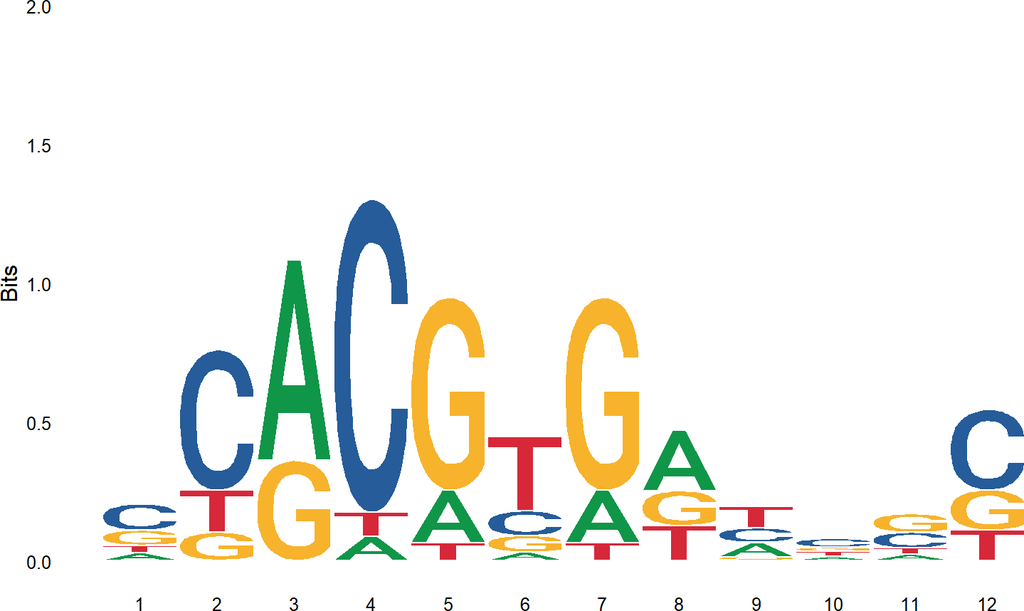

```r
length(plot$logo_plot)
## [1] 12
alignindex = 4
print(plot$logo_plot[[alignindex]])
```

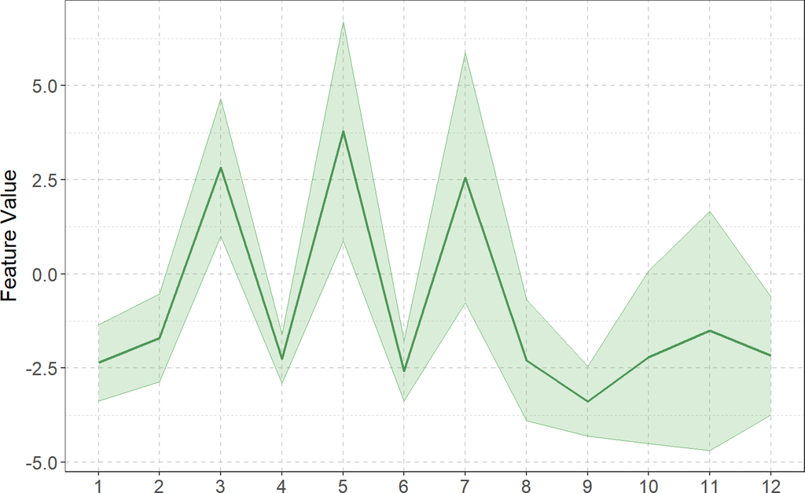

```r
print(plot$area_plot[[alignindex]])
```

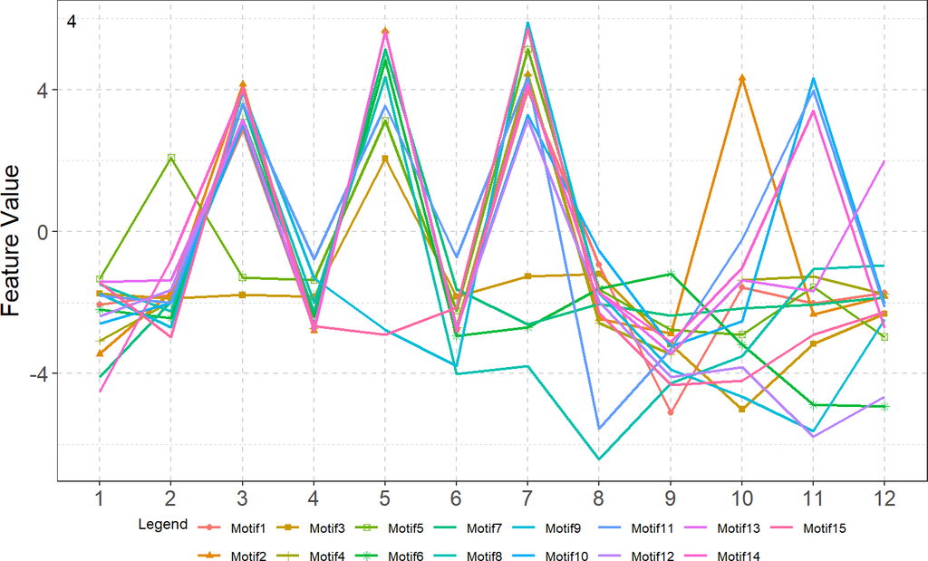

```r
print(plot$line_plot[[alignindex]])
```

#### 4.1.1.8 Use the shape motif visualizer with method ‘distance’

The second method is “distance”, this method does not have the advantage of “pearson” to filter motifs, but it can show the whole picture of each alignment:

```r
motif_data_frame = gr_input_merge_result$motif_data_frame

motif_shape_data = gr_input_merge_result$motif_shape_data

motif_vis_dist = motif_visualizer(
  motif_data_frame,
  motif_shape_data,
  motifFrequency = 0.5,
  shapeIndex = 4,
  motifLength = 12,
  align_method = "distance",
  ref_number = 1,
  input_form = 1,
  continue_alignment = 1,
  top_motif = 25,
  threshold = 0.7
)
```

The contents of `motif_visualizer` output results.

```r
seq_list_set = motif_vis_dist$align_motif_sequence

align_df = motif_vis_dist$align_motif_dataframe

shape_dfm_set = align_df$motif_shape_df_melt

area_dfm_set = align_df$motif_area_df_melt
```

#### 4.1.1.9 visualize shape motifs

Get the plot of alignment result:

```r
plot = get_plot(shape_dfm_set, area_dfm_set, seq_list_set, shapeIndex = 4)
```

View one of the results of the motif alignment:

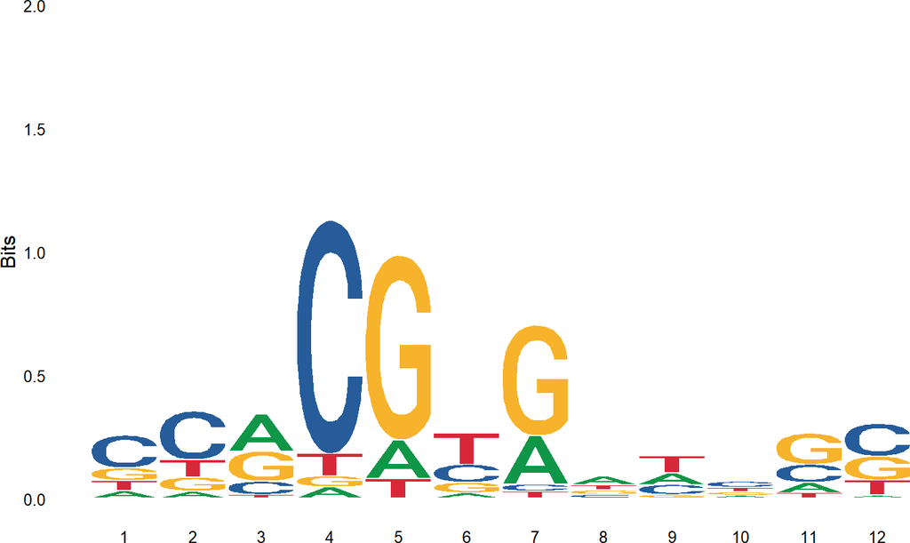

```r
alignindex = 4
print(plot$logo_plot[[alignindex]])
```

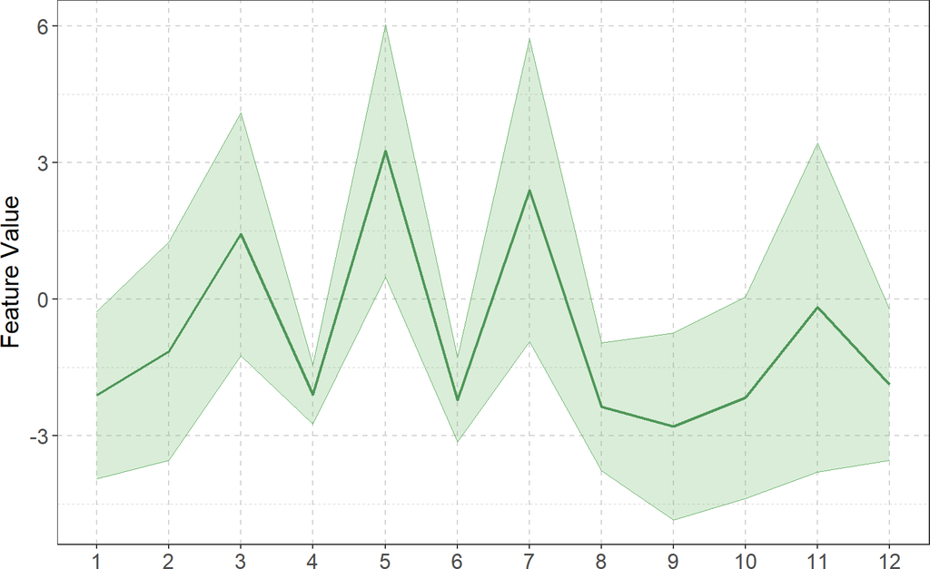

```r
print(plot$area_plot[[alignindex]])
```

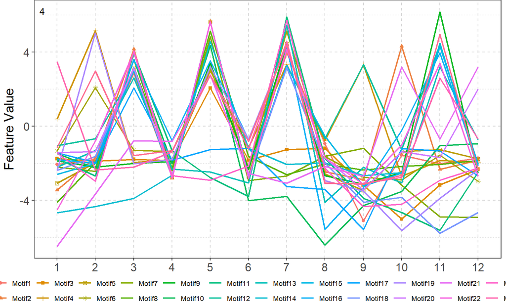

```r
print(plot$line_plot[[alignindex]])
```

#### 4.1.1.10 Use the shape motif visualizer with all shape features

We also provide the alignment method for multiple features:

```r
motif_data_frame = gr_input_merge_result$motif_data_frame

motif_shape_data = gr_input_merge_result$motif_shape_data

motif_vis_all = motif_visualizer(
  motif_data_frame,
  motif_shape_data,
  motifFrequency = 0.5,
  shapeIndex = "all",
  motifLength = 12,
  align_method = "pearson",
  ref_number = 1,
  input_form = 1,
  continue_alignment = 1,
  top_motif = 25,
  threshold = 0.4
)
```

The contents of `motif_visualizer` output results.

```r
seq_list_set = motif_vis_all$align_motif_sequence

align_df = motif_vis_all$align_motif_dataframe

shape_dfm_set = align_df$motif_shape_df_melt[[1]]

area_dfm_set = align_df$motif_area_df_melt[[1]]
```

#### 4.1.1.11 visualize shape motifs

Get the plot of alignment result:

```r
plot = get_plot(shape_dfm_set, area_dfm_set, seq_list_set, shapeIndex = 1)
```

View one of the results of the motif alignment:

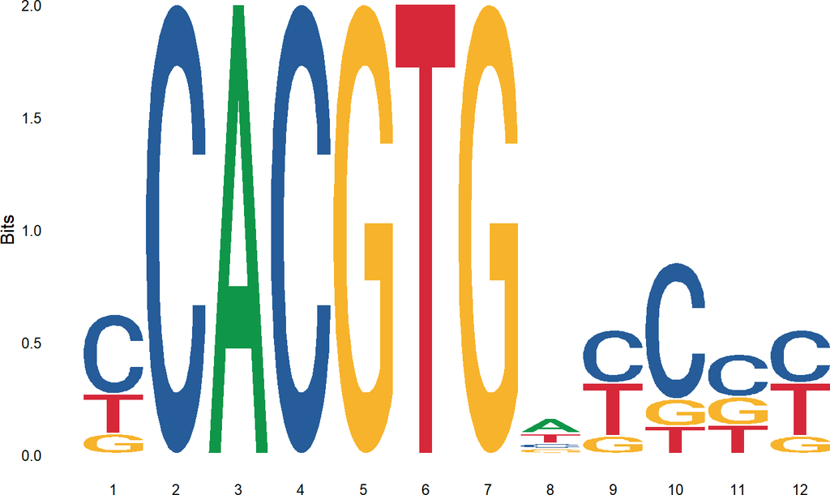

```r
alignindex = 4
print(plot$logo_plot[[alignindex]])
```

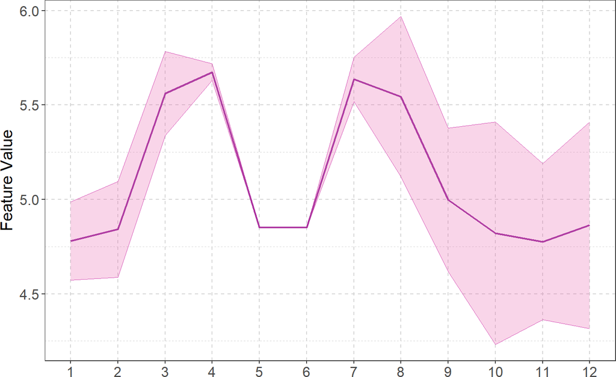

```r
print(plot$area_plot[[alignindex]])
```

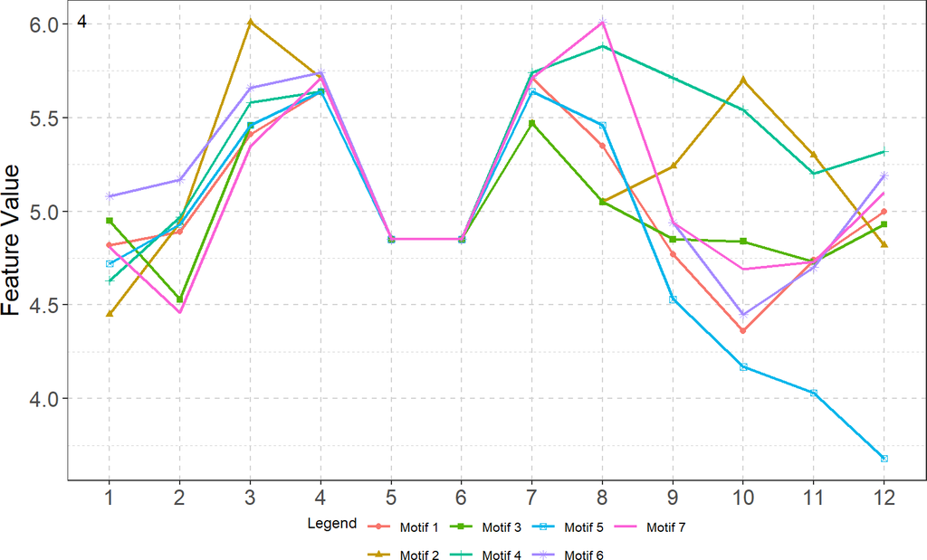

```r
print(plot$line_plot[[alignindex]])
```

### 4.1.2 Single shape feature

The package also supports motif discovery on single shape features.

#### 4.1.2.1 Get shape data with single shape features

By specifying a certain shape feature (e.g. 1 to 5), the function `gr_input` can generate the shape data of the feature.

```r
gr_input_result = gr_input(
  A549_MAX_gr,
  peakLength = 100,
  total_peak_number = 100,
  fasta_name = "fasta.fa",
  shapeind = 4,
  sort_by = "signalValue",
  sort_descend = TRUE
)
```

```
## [1] "Extracting peaks, please wait..."
## Reading the input sequence......
## Reading the input sequence......
## Reading the input sequence......
## Reading the input sequence......
## Reading the input sequence......
## Reading the input sequence......
## Reading the input sequence......
## Reading the input sequence......
## Reading the input sequence......
## Reading the input sequence......
## Reading the input sequence......
## Reading the input sequence......
## Reading the input sequence......
## Reading the input sequence......
## [1] "the modified gr file and DNA shape data is returned as '$gr_file' and '$dna_shape_data'"
```

User can check the View pre-processed GRanges file results by:

```r
gr_input_result$gr_file
## GRanges object with 100 ranges and 0 metadata columns:
##         seqnames              ranges strand
##            <Rle>           <IRanges>  <Rle>
##     [1]     chr1     6762037-6762136      *
##     [2]     chr1   26758579-26758678      *
##     [3]     chr1   38478121-38478220      *
##     [4]     chr1 154531328-154531427      *
##     [5]     chr2   27440266-27440365      *
##     ...      ...                 ...    ...
##    [96]    chr19   50529259-50529358      *
##    [97]    chr19   55987543-55987642      *
##    [98]    chr19   56015192-56015291      *
##    [99]    chr20       343207-343306      *
##   [100]    chr20     3788889-3788988      *
##   -------
##   seqinfo: 298 sequences (2 circular) from hg19 genome
```

User can check the obtained DNA shape data with single shape feature:

```r
gr_input_result$dna_shape_data
```

Here the DNA shape data of the top 10 peaks is shown:

```r
gr_input_result$dna_shape_data[, , 1:10]
```

```
##         [,1]  [,2]  [,3]  [,4]  [,5]  [,6]  [,7]  [,8]  [,9] [,10]
##   [1,] -0.92 -2.70 -3.06  2.06 -0.88 -3.29 -2.37 -2.40  4.32 -1.30
##   [2,] -2.07 -3.68 -3.13 -1.84 -2.61 -0.94 -2.62  6.17 -3.43  3.55
##   [3,] -2.47 -1.71 -3.65 -1.79 -2.45  7.73 -1.97 -2.68 -2.22 -0.97
##   [4,]  4.37 -3.02 -1.98 -2.21 -3.46 -3.85 -1.89 -4.80 -2.92  4.54
##   [5,] -1.22 -2.94 -2.02 -2.33 -2.75 -1.28 -1.75 -3.58  2.76 -3.42
##   [6,]  2.73  4.33  2.58 -2.33 -2.10 -1.66  2.06 -2.28 -0.66 -2.82
##   [7,] -1.32 -2.63 -2.50 -2.71 -1.15 -3.47 -1.84 -5.05 -2.54 -3.80
##   [8,] -1.58 -2.12 -2.87 -2.94 -2.61 -3.42 -1.79  5.03  4.35 -2.67
##   [9,]  2.85 -2.21 -2.48  4.96  4.70  0.20 -2.21 -2.81 -2.59 -1.21
##  [10,] -1.94 -3.67 -0.90 -2.57 -2.12  5.35 -2.71 -1.70 -1.92 -1.50
##  [11,] -2.03 -0.79  4.35 -3.08  4.00 -2.43 -3.27 -1.19 -2.38  3.74
##  [12,] -2.35 -1.42 -1.47 -1.09 -2.16 -3.16  3.17  3.87 -1.64 -1.88
##  [13,]  4.92 -2.21 -1.77 -2.34 -2.01 -4.67 -1.36 -0.78  2.77 -1.83
##  [14,] -2.35 -1.85 -2.71 -1.19  3.46 -5.58 -1.42  3.54 -2.69 -2.71
```

[output cut: 86 more lines]

#### 4.1.2.2 Run ShapeMotifEM (SMEM) algorithm

Next, users can use the DNA shape data generated in the previous step for motif discovery.

```r
dna_shape_data = gr_input_result$dna_shape_data

EM_result = SMEM(
  dna_shape_data,
  filename = "A549_MAX_gr_single",
  peakCount = 50,
  motifLength = 12,
  motifCount = 2,
  replicates = 50,
  tolerance = 1e-06
)

EM_result
```

The top 10 rows of the result is shown as an example:

```r
EM_result[1:10,]
```

```
##       [,1] [,2] [,3] [,4] [,5] [,6] [,7] [,8] [,9] [,10] [,11] [,12] [,13]
##  [1,]   31   63   22    9   44   40   58   23    5    50    50    31    71
##  [2,]   65   66   31   30   82   45   82   73   72    63    41    45    25
##  [3,]   65   29   49   30   53   45   82   73   15    63    43     0    37
##  [4,]   67   24   26   25   77   40   77   68   67    78    50    40    34
##  [5,]   67   24   79   85   44   40   20   68   28    78    55    80    34
##  [6,]   59   63   82   88   44   40   58   23    5    50    50    92     4
##  [7,]   51   61   34   80   48   50   15   76   16    64    42    75    69
##  [8,]   67   24   26   25   77   40   77   68   67    78    50    40    34
##  [9,]   80   63   28   80   50   46   15   76   16    73    42    75    14
## [10,]   72   29   31   83    6   40   18   68   72    83    53    78    63
##       [,14] [,15] [,16] [,17] [,18] [,19] [,20] [,21] [,22] [,23] [,24] [,25]
##  [1,]    43    57    89    55    61    83    25    21    21    42    25    90
##  [2,]    53    76    13    41    58    19    20    60    47    20    62    58
##  [3,]    88    67    13    41    58    19    20    60    58    18    44    58
```

[output cut: 84 more lines]

#### 4.1.2.3 Merge results

Use function `gr_motif_merge` to process the results.

```r
gr_file = gr_input_result$gr_file

motif_location_array = EM_result

gr_input_merge_result = gr_motif_merge(motif_location_array,
                                         gr_file,
                                         motifLength = 12,
                                         filename = "A549_MAX_gr_single")
```

The output form of this function is the same as in the multi-feature case. All shape features are output in case other shape features at the same location will be analyzed.

```r
gr_input_merge_result$motif_data_frame

gr_input_merge_result$motif_shape_data
```

Here is an example of merged output.

```r
gr_input_merge_result$motif_data_frame[1:10,]
```

```
##    peakNo. seriesNo. chrNo. location genoStart  genoEnd motiflength
## 1        1         1   chr1        3   6762040  6762060          12
## 2        1         2   chr1       17   6762054  6762073          12
## 3        1         3   chr1       29   6762066  6762079          12
## 4        1         4   chr1       44   6762081  6762102          12
## 5        1         5   chr1       56   6762093  6762115          12
## 6        1         6   chr1       69   6762106  6762128          12
## 7        1         7   chr1       83   6762120  6762138          12
## 8        2         1   chr1        1  26758580 26758591          12
## 9        2         2   chr1       23  26758602 26758621          12
## 10       2         3   chr1       57  26758636 26758656          12
##    mergerMotifLength motifFrequency
## 1                 21           0.03
## 2                 20           0.03
## 3                 14           0.10
## 4                 22           0.12
## 5                 23           0.59
## 6                 23           0.10
## 7                 19           0.03
## 8                 12           0.03
## 9                 20           0.26
## 10                21           0.63
```

```r
gr_input_merge_result$motif_shape_data[1]
```

```
## [[1]]
## [[1]][[1]]
##        [,1]  [,2]  [,3]  [,4]  [,5]  [,6]  [,7]  [,8]  [,9] [,10] [,11] [,12]
##  [1,]  5.09  5.20  5.51  5.37  5.09  5.41  5.41  4.77  4.97  5.69  5.69  4.97
##  [2,] 33.11 35.72 32.41 33.52 36.24 32.32 36.28 34.19 31.49 34.19 31.49 34.03
##  [3,] -7.38 -4.73 -4.25 -3.73 -3.17 -3.39 -3.39 -2.82 -1.23 -6.51 -6.51 -1.23
##  [4,]  4.37 -1.22  2.73 -1.32 -1.58  2.85 -1.94 -2.03 -2.35  4.92 -2.35 -2.01
##  [5,] -5.25 -4.86 -4.76 -5.10 -5.17 -5.12 -5.12 -5.21 -5.65 -6.90 -6.90 -5.65
##  [6,]  3.46  3.39  3.33  3.33  3.38  3.31  3.40  3.44  3.27  3.28  3.27  3.44
##  [7,]  0.03  0.00 -0.01  0.10 -0.01  0.00  0.04 -0.10 -0.23  0.00  0.23  0.10
##  [8,] -1.65 -1.55 -1.62 -1.71 -1.56 -1.58 -1.58 -1.85 -1.76 -1.46 -1.76 -1.87
##  [9,] -0.30 -0.02 -0.59  0.17  0.12  0.00  0.03 -1.32  1.89  0.00 -1.89  1.27
## [10,]  5.02 -1.59  1.65  0.16  0.28 -0.35  0.35 -0.23 -4.00 -0.58  0.58  4.00
## [11,]  0.64  0.46  0.44  0.28  0.24  0.39  0.39  0.40  0.19 -0.83 -0.83  0.19
## [12,]  0.26 -0.27  0.24 -0.26 -0.27  0.25 -0.25  0.30  0.25 -0.10  0.10 -0.25
```

[output cut: 209 more lines]

#### 4.1.2.4 Use the shape motif visualizer

Use function `motif_visualizer` with method “pearson” to visualize the DNA shape motif. Note that the `shapeIndex` here needs to be the same as the input in `gr_input`.

```r
motif_data_frame = gr_input_merge_result$motif_data_frame

motif_shape_data = gr_input_merge_result$motif_shape_data

motif_vis_pearson = motif_visualizer(
  motif_data_frame,
  motif_shape_data,
  motifFrequency = 0.5,
  shapeIndex = 4,
  motifLength = 12,
  align_method = "pearson",
  ref_number = 1,
  input_form = 1,
  continue_alignment = 1,
  top_motif = 25,
  threshold = 0.6
)
```

The contents of `motif_visualizer` output results.

```r
seq_list_set = motif_vis_pearson$align_motif_sequence

align_df = motif_vis_pearson$align_motif_dataframe

shape_dfm_set = align_df$motif_shape_df_melt

area_dfm_set = align_df$motif_area_df_melt
```

#### 4.1.2.5 visualize shape motifs

Check the motif alignment score and records:

```r
# Check the alignment score
motif_vis_pearson$align_score
```

```
##                   [,1]       [,2]       [,3]      [,4]      [,5]      [,6]
## align_index 12.0000000 11.0000000 10.0000000 9.0000000 8.0000000 6.0000000
## align_score  0.6795138  0.6861294  0.6947654 0.7119273 0.7137102 0.7367264
##                  [,7]      [,8]      [,9]     [,10]     [,11]     [,12]
## align_index 7.0000000 3.0000000 5.0000000 4.0000000 1.0000000 2.0000000
## align_score 0.7396341 0.7440846 0.7452678 0.7503798 0.7766069 0.7890349
```

```r
# Check the number of elements of each alignment
unlist(lapply(seq_list_set, length))
```

```
##  [1] 14 16 22 21 23 22 24 15 17 17 10 10
```

Get the plot of alignment result:

```r
plot = get_plot(shape_dfm_set, area_dfm_set, seq_list_set, shapeIndex = 4)
```

View one of the results of the motif alignment:

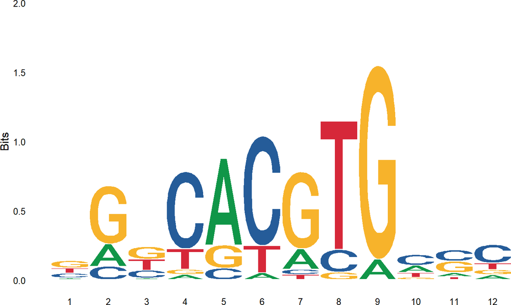

```r
alignindex = 4
print(plot$logo_plot[[alignindex]])
```

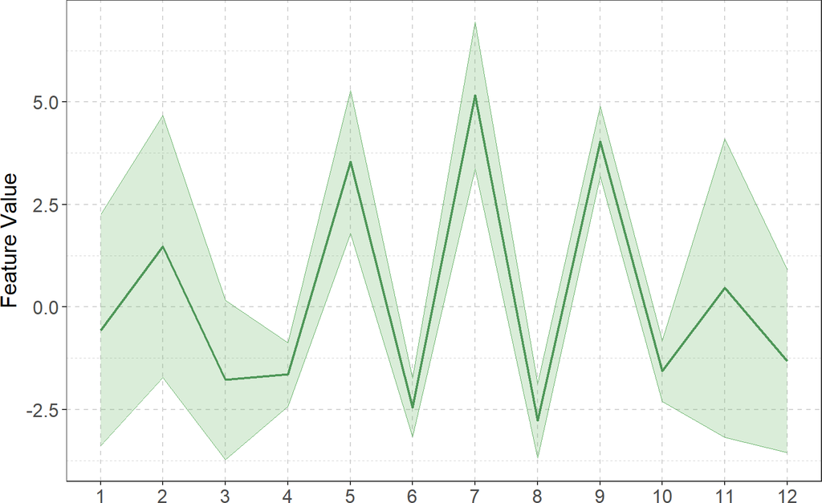

```r
print(plot$area_plot[[alignindex]])
```

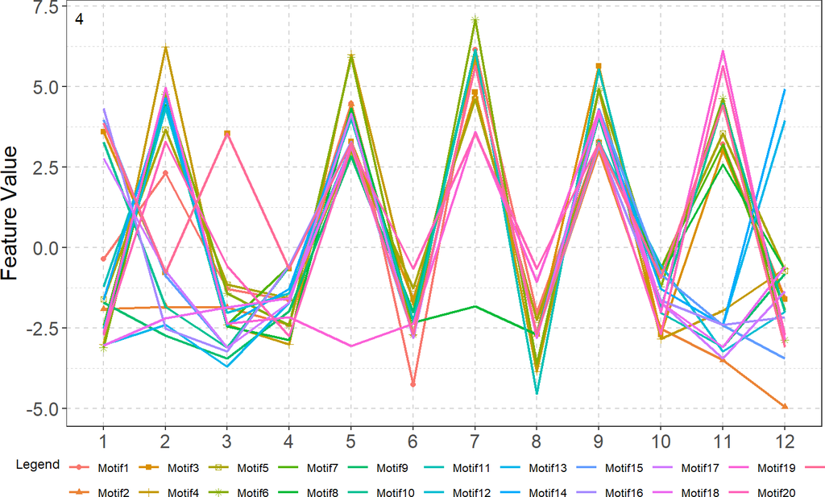

```r
print(plot$line_plot[[alignindex]])
```

#### 4.1.2.6 Use the shape motif visualizer

Use function `motif_visualizer` with method “distance” to visualize the DNA shape motif. Similarly, the `shapeIndex` here needs to be the same as the input in `gr_input`.

```r
motif_data_frame = gr_input_merge_result$motif_data_frame

motif_shape_data = gr_input_merge_result$motif_shape_data

motif_vis_dist = motif_visualizer(
  motif_data_frame,
  motif_shape_data,
  motifFrequency = 0.5,
  shapeIndex = 4,
  motifLength = 12,
  align_method = "distance",
  ref_number = 1,
  input_form = 1,
  continue_alignment = 1,
  top_motif = 25,
  threshold = 0.6
)
```

The contents of `motif_visualizer` output results.

```r
seq_list_set = motif_vis_dist$align_motif_sequence

align_df = motif_vis_dist$align_motif_dataframe

shape_dfm_set = align_df$motif_shape_df_melt

area_dfm_set = align_df$motif_area_df_melt
```

#### 4.1.2.7 visualize shape motifs

Get the plot of alignment result:

```r
plot = get_plot(shape_dfm_set, area_dfm_set, seq_list_set, shapeIndex = 4)
```

View one of the results of the motif alignment:

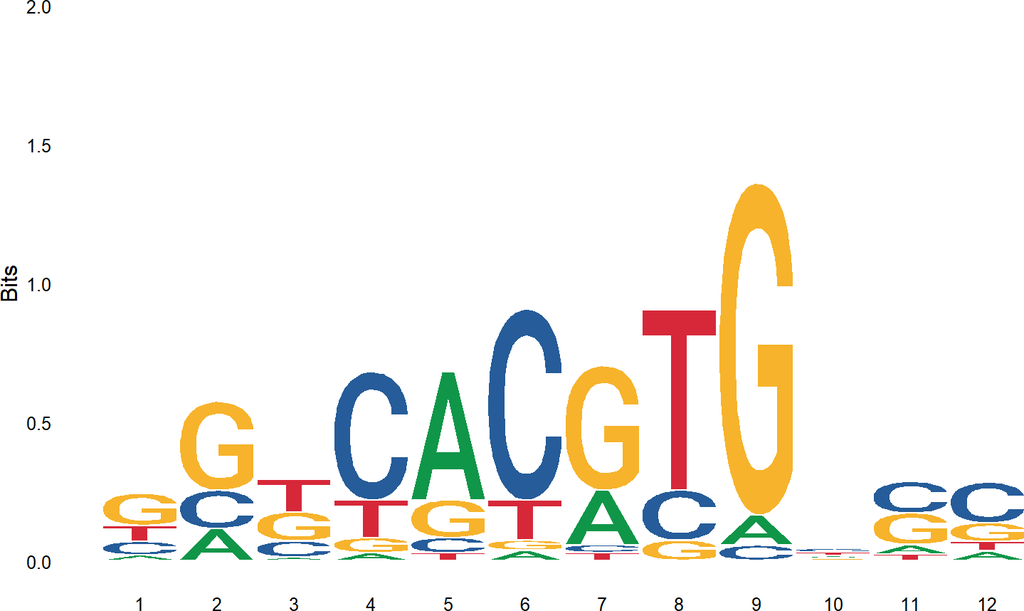

```r
alignindex = 4
print(plot$logo_plot[[alignindex]])
```

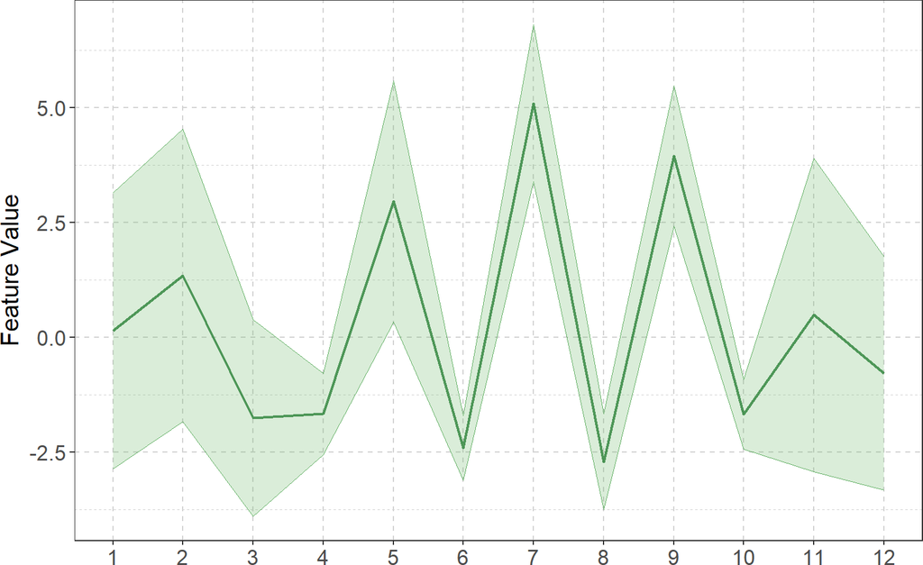

```r
print(plot$area_plot[[alignindex]])
```

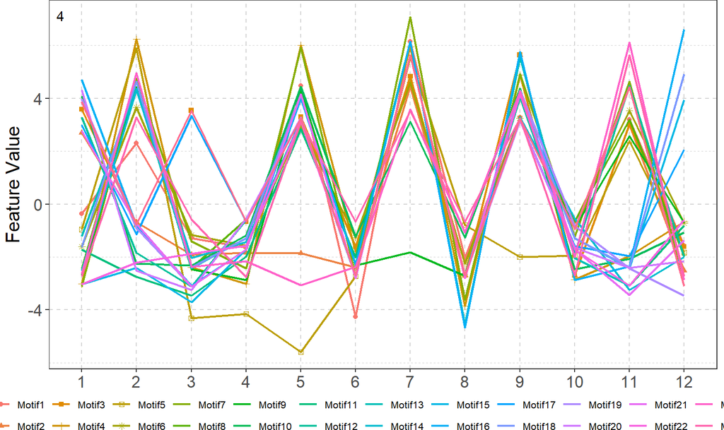

```r
print(plot$line_plot[[alignindex]])
```

## 4.2 DNA Shape Motif Discovery with FASTA Input

### 4.2.1 Multiple Features

#### 4.2.1.1 Get shape data with multiple shape features

When using the function `gr_input` in the previous part, the function generates a FASTA file: “fasta.fa” in the working directory for us. Here we will use this file for demonstration.

Noted that each peak summit sequence in the FASTA must be the same length. In addition, due to the calculation rules of DNA shape data, the actual peak length used in the discovery is equal to the length of the peak sequence minus 4 (i.e. sequncen length = 104, then peak length = 100).

```r
length(readDNAStringSet(paste0("fasta.fa")))
```

```
## [1] 100
```

Sequence of the top 5 peaks in the “fasta.fa” file:

```r
readDNAStringSet(paste0("fasta.fa"))[1:5]
```

```
## DNAStringSet object of length 5:
##     width seq                                               names
## [1]   104 CGGGACGCGGCGCCTAGGCAGCC...CGTGGCTGCGTCCTCGGGGGCCT seq1
## [2]   104 TCAACCCTGTCTTCCCCAGCTGG...CTCTCACCCGCGCCGGCTTCCAC seq2
## [3]   104 CTAAGCCCAGCTCAGACGGAGGC...GGTAGCGTGGACAGGCGCTAGCG seq3
## [4]   104 CCCGCCCCCCTGTTCTCGCCTGC...TTTGCGTATGTCGTGCGTGCTTG seq4
## [5]   104 CCGAGGCTCCTACGCTGCCGCGC...CCTCACGTGGTTCCAGTGGAGTT seq5
```

function `fasta_input` can be used to obtain dna shape data that meets subsequent input requirements. In addition to the input data, `fasta_input` function contains the following parameters:

1. `fasta_file`: Path to the FASTA file containing the DNA sequence.
2. `shapeind`: Users can choose to perform shape motif discovery on either multiple shape features or a single shape feature by setting the shape index. The default value is “all”. Additionally, integer from 1 to 5 correspond to the features “MGW,” “HelT,” “ProT,” “Roll,” and “EP,” respectively.

```r
fasta_file = "fasta.fa"

fasta_input_result = fasta_input(fasta_file, shapeind = "all")
```

[output not shown]

```r
fasta_input_result
```

An example of the shape data:

```r
fasta_input_result[, , 1]
```

```
##        [,1]  [,2]  [,3]  [,4]  [,5]  [,6]  [,7]  [,8]  [,9] [,10] [,11] [,12]
##  [1,]  4.95  4.90  5.02  5.09  5.20  5.51  5.37  5.09  5.41  5.41  4.77  4.97
##  [2,] 34.05 36.05 34.11 33.11 35.72 32.41 33.52 36.24 32.32 36.28 34.19 31.49
##  [3,] -2.56 -5.28 -8.11 -7.38 -4.73 -4.25 -3.73 -3.17 -3.39 -3.39 -2.82 -1.23
##  [4,] -0.92 -2.07 -2.47  4.37 -1.22  2.73 -1.32 -1.58  2.85 -1.94 -2.03 -2.35
##  [5,] -5.44 -5.50 -7.29 -5.25 -4.86 -4.76 -5.10 -5.17 -5.12 -5.12 -5.21 -5.65
##  [6,]  3.43  3.23  3.33  3.46  3.39  3.33  3.33  3.38  3.31  3.40  3.44  3.27
##  [7,]  0.02 -0.20  0.24  0.03  0.00 -0.01  0.10 -0.01  0.00  0.04 -0.10 -0.23
##  [8,] -1.77 -1.40 -1.50 -1.65 -1.55 -1.62 -1.71 -1.56 -1.58 -1.58 -1.85 -1.76
##  [9,]  0.92  0.32 -0.51 -0.30 -0.02 -0.59  0.17  0.12  0.00  0.03 -1.32  1.89
## [10,]  1.90 -1.50  3.23  5.02 -1.59  1.65  0.16  0.28 -0.35  0.35 -0.23 -4.00
## [11,]  0.18  0.34 -0.30  0.64  0.46  0.44  0.28  0.24  0.39  0.39  0.40  0.19
## [12,] -0.28 -0.31  0.10  0.26 -0.27  0.24 -0.26 -0.27  0.25 -0.25  0.30  0.25
## [13,]  0.09 -0.05 -0.01 -0.03  0.00  0.02  0.05  0.07  0.06  0.06  0.02  0.16
## [14,] -0.04 -0.05 -0.02 -0.02 -0.03 -0.03 -0.04 -0.04 -0.03 -0.03 -0.04 -0.03
```

[output cut: 120 more lines]

#### 4.2.1.2 Run ShapeMotifEM (SMEM) algorithm

Run the algorithm SMEM:

```r
dna_shape_data = fasta_input_result

EM_result = SMEM(
  dna_shape_data,
  filename = "A549_MAX_fasta_mul",
  peakCount = 50,
  motifLength = 12,
  motifCount = 2,
  replicates = 50,
  tolerance = 1e-06
)

EM_result
```

The dimension of the result and the top 10 rows of the result:

```r
dim(EM_result)
```

```
## [1] 100 100
```

```r
EM_result[1:10,]
```

```
##       [,1] [,2] [,3] [,4] [,5] [,6] [,7] [,8] [,9] [,10] [,11] [,12] [,13]
##  [1,]   67   24   44   23   48   40   24   21   37    58    36    53    46
##  [2,]   46   64   29   28   80   43   33   71   13    61    39    56    63
##  [3,]   46   64   29   28   51   43   27   71   70    61    39    56    49
##  [4,]   47    8   35   78   47   21   37   63   36    35    96    20    67
##  [5,]   80   75   76   68    4   60   78   59   55    69    66     7    13
##  [6,]   59    0   65   79   47   10   73    2   36    31    50    52    21
##  [7,]   41    2   29   72   82   15   31   57   30    29    90    14    61
##  [8,]   46   64   29   28   51   43   27   71   70    61    39    56    49
##  [9,]   67   61   26   23   77   40   30   68   10    58    36    53     8
## [10,]   41    0   29   72   81   15   31   56   29    20    43     3    61
##       [,14] [,15] [,16] [,17] [,18] [,19] [,20] [,21] [,22] [,23] [,24] [,25]
##  [1,]     2    21    39     1    53    50    15    19    53    52    69    37
##  [2,]    51    74    11    39    56    53    18    58    56    20    60     7
##  [3,]    51    74    11    39    56    53    18    58    56    55    36     7
```

[output cut: 84 more lines]

#### 4.2.1.3 Run ShapeMotifEM (SMEM_Gibbs) algorithm

The algorithm SMEM_Gibbs can be applied in the same manner:

```r
EM_Gibbs_result = SMEM_Gibbs(
  dna_shape_data,
  filename = "A549_MAX_fasta_mul",
  peakCount = 50,
  motifLength = 12,
  motifCount = 2,
  replicates = 50,
  tolerance = 1e-06
)
```

#### 4.2.1.4 Merge results

To merge the results with FASTA form input, function `fasta_motif_merge` can be used. The parameter of the function include:

1. `motif_location_array`: The motif location array output by function `SMEM` or `SMEM_Gibbs`.
2. `fasta_file`: Path to the FASTA file containing the DNA sequence.
3. `motifLength`: The same motif length as used in the previous functions.
4. `filename`: The file name of the final output data frame.

```r
motif_location_array = EM_result

fasta_input_merge_result = fasta_motif_merge(motif_location_array,
                                             fasta_file,
                                             motifLength = 12,
                                             filename = "A549_MAX_fasta_mul")
```

The output of `fasta_motif_merge` has the same structure as the output of `gr_motif_merge`. However, the `motif_data_frame` here records the specific position of each motif on its corresponding sequence, as well as the sequence corresponding to each motif, and the frequency of occurrence

```r
fasta_input_merge_result$motif_data_frame

fasta_input_merge_result$motif_shape_data
```

An output example of the function `fasta_motif_merge`:

```r
fasta_input_merge_result$motif_data_frame[1:10,]
##    peakNo. seriesNo. locationStrat locationEnd motifLength mergerMotifLength
## 1        1         1            11          33          12                23
## 2        1         2            39          60          12                22
## 3        1         3            51          71          12                21
## 4        1         4            67          89          12                23
## 5        1         5            80          93          12                14
## 6        2         1             8          21          12                14
## 7        2         2            21          42          12                22
## 8        2         3            34          52          12                19
## 9        2         4            46          60          12                15
## 10       2         5            61          80          12                20
##                   sequence motifFrequency
## 1  CCTAGGCAGCCCTGGCGGGGTGA           0.05
## 2   CGGGTGTCTCTTCGTGCTCCCA           0.44
## 3    CGTGCTCCCAATGGACGCGTG           0.41
## 4  GCGTGGCACGCGGCGTGGCTGCG           0.06
## 5           CGTGGCTGCGTCCT           0.02
## 6           TCTTCCCCAGCTGG           0.12
## 7   GTCTCCCAGCACGTGGCCTGGA           0.03
## 8      TGGCCTGGAGCCCAGCCTC           0.05
## 9          CAGCCTCCCGCCCCG           0.02
## 10    CTCGGTCACGTGAGCCTGGC           0.29

fasta_input_merge_result$motif_shape_data[1]
## [[1]]
## [[1]][[1]]
##        [,1]  [,2]  [,3]  [,4]  [,5]  [,6]  [,7]  [,8]  [,9] [,10] [,11] [,12]
##  [1,]  4.77  4.97  5.69  5.69  4.97  4.82  5.41  5.67  4.95  4.61  4.73  4.85
##  [2,] 34.19 31.49 34.19 31.49 34.03 36.24 34.12 31.23 37.23 33.52 34.03 31.14
##  [3,] -2.82 -1.23 -6.51 -6.51 -1.23 -2.38 -3.20 -6.76 -1.20 -2.48 -1.88 -0.14
##  [4,] -2.03 -2.35  4.92 -2.35 -2.01 -1.88  3.46 -2.37 -2.62 -2.07 -2.58 -3.13
##  [5,] -5.21 -5.65 -6.90 -6.90 -5.65 -5.20 -5.08 -6.71 -5.43 -5.43 -5.05 -5.52
##  [6,]  3.44  3.27  3.28  3.27  3.44  3.40  3.29  3.27  3.46  3.40  3.46  3.28
##  [7,] -0.10 -0.23  0.00  0.23  0.10 -0.02 -0.28  0.24  0.01 -0.09 -0.12 -0.27
##  [8,] -1.85 -1.76 -1.46 -1.76 -1.87 -1.62 -1.42 -1.69 -1.68 -1.83 -1.91 -1.76
##  [9,] -1.32  1.89  0.00 -1.89  1.27 -0.34  1.06 -2.40  1.00 -0.51 -1.15  2.33
## [10,] -0.23 -4.00 -0.58  0.58  4.00  0.41  0.44  1.06  3.57  0.64 -1.06 -4.67
## [11,]  0.40  0.19 -0.83 -0.83  0.19  0.44  0.33 -0.70  0.27  0.43  0.37  0.35
## [12,]  0.30  0.25 -0.10  0.10 -0.25 -0.30  0.26  0.09 -0.24  0.28  0.30  0.26
## [13,]  0.02  0.16  0.00  0.00  0.16  0.03  0.09 -0.05  0.16  0.01  0.01  0.16
## [14,] -0.04 -0.03 -0.03 -0.03 -0.03 -0.04 -0.03 -0.03 -0.02 -0.04 -0.05 -0.01
##       [,13] [,14] [,15] [,16] [,17] [,18] [,19] [,20] [,21] [,22] [,23]
##  [1,]  5.40  5.43  5.06  5.29  5.30  4.94  4.58  4.77  5.40  6.01  4.94
##  [2,] 34.16 33.45 36.33 32.30 33.31 33.53 34.34 34.09 34.38 35.40 34.75
##  [3,] -5.54 -3.34 -2.98 -3.13 -2.75 -1.95 -2.37 -5.89 -7.04 -6.82 -7.96
##  [4,]  2.59 -1.59 -1.96  2.06 -1.75 -2.08 -1.44 -3.10  3.92 -1.71 -3.09
##  [5,] -6.72 -5.19 -5.16 -5.09 -5.14 -5.31 -5.66 -5.32 -6.98 -5.13 -7.65
##  [6,]  3.33  3.33  3.40  3.31  3.35  3.40  3.46  3.35  3.29  3.20  3.38
##  [7,]  0.27  0.10 -0.03  0.00  0.14  0.10  0.01 -0.29  0.24 -0.18  0.24
##  [8,] -1.47 -1.75 -1.57 -1.61 -1.79 -1.86 -1.85 -1.55 -1.25 -1.38 -1.56
##  [9,] -1.21  0.54  0.15 -0.48  0.11  0.39  0.64  0.81 -0.74  0.46 -0.81
## [10,] -0.99  0.08  0.47  0.43  1.59  1.72 -0.38 -4.72 -2.60 -0.80  4.35
## [11,] -0.38  0.20  0.32  0.42  0.31  0.27  0.41  0.48 -0.59  0.26 -0.39
## [12,] -0.09 -0.27 -0.28  0.25 -0.26 -0.28 -0.29 -0.29 -0.11 -0.28  0.11
## [13,] -0.05  0.09  0.06  0.04  0.08  0.05 -0.01 -0.04 -0.02  0.05  0.01
## [14,] -0.02 -0.04 -0.04 -0.03 -0.03 -0.04 -0.04 -0.04 -0.03 -0.04 -0.02
##
## [[1]][[2]]
##        [,1]  [,2]  [,3]  [,4]  [,5]  [,6]  [,7]  [,8]  [,9] [,10] [,11] [,12]
##  [1,]  5.51  5.30  4.70  4.77  5.31  5.49  4.99  5.04  5.00  4.68  4.52  4.92
##  [2,] 32.33 33.46 34.48 34.25 34.88 34.20 36.33 31.73 35.86 32.37 35.07 35.61
##  [3,] -4.25 -2.75 -3.53 -5.89 -8.57 -7.25 -8.49 -3.46 -6.62 -3.22 -8.18 -9.80
##  [4,]  2.51 -1.75 -1.01 -2.97  4.09 -2.40 -1.86 -1.66 -1.46 -2.02 -3.61 -0.50
##  [5,] -4.76 -5.14 -5.59 -5.32 -7.06 -5.39 -7.28 -5.70 -7.34 -5.82 -7.96 -7.77
##  [6,]  3.31  3.37  3.48  3.37  3.31  3.34  3.30  3.33  3.38  3.43  3.12  3.34
##  [7,]  0.01  0.13  0.04 -0.31  0.30 -0.24  0.17 -0.15  0.15 -0.26  0.02  0.29
##  [8,] -1.61 -1.79 -1.83 -1.54 -1.27 -1.52 -1.46 -1.73 -1.64 -1.79 -1.27 -1.43
##  [9,] -0.70  0.21  0.74  0.81 -0.98  0.96 -1.56  2.30 -1.79  2.08  2.04 -1.45
## [10,]  1.65  1.59  0.44 -4.72 -4.94 -4.45 -5.34 -2.75 -2.57 -3.02 -6.57  0.10
## [11,]  0.44  0.31  0.27  0.48 -0.67  0.41 -0.11  0.16  0.00  0.32 -0.96 -1.02
## [12,]  0.24 -0.26 -0.27 -0.29 -0.11 -0.26 -0.08  0.27 -0.06  0.28 -0.13 -0.10
## [13,]  0.02  0.08  0.04 -0.04 -0.02  0.08  0.01  0.10 -0.08  0.09  0.05 -0.22
## [14,] -0.03 -0.03 -0.04 -0.04 -0.03 -0.03 -0.01 -0.03 -0.02 -0.03 -0.02 -0.03
##       [,13] [,14] [,15] [,16] [,17] [,18] [,19] [,20] [,21]  [,22]
##  [1,]  5.21  5.29  5.74  5.43  5.10  5.05  4.85  4.93  5.44   5.30
##  [2,] 33.86 33.78 34.39 36.64 31.42 35.66 33.59 32.99 34.34  35.00
##  [3,] -6.66 -7.95 -8.40 -3.79 -0.94 -6.07 -4.60 -2.42 -3.45 -10.72
##  [4,]  5.43 -2.23  3.02 -2.00 -2.59 -1.73 -0.97 -1.09  5.85  -2.35
##  [5,] -5.30 -5.22 -6.68 -5.27 -5.61 -7.34 -5.23 -5.54 -5.39  -7.32
##  [6,]  3.51  3.32  3.25  3.44  3.25  3.29  3.46  3.34  3.48   3.15
##  [7,]  0.07 -0.29  0.32  0.03 -0.21  0.16 -0.04 -0.11 -0.45  -0.12
##  [8,] -1.57 -1.44 -1.29 -1.65 -1.72 -1.55 -1.85 -1.85 -1.46  -1.19
##  [9,]  0.24  0.53 -1.08 -0.62  2.26 -0.64 -1.02 -0.53  3.10  -2.30
## [10,]  2.20 -5.92 -4.21 -1.44 -3.75 -0.19  2.36 -1.24  0.56  -3.46
## [11,]  0.40  0.48 -0.85  0.28  0.24 -0.25  0.37  0.31  0.20  -0.94
## [12,]  0.29 -0.26 -0.11 -0.25  0.25 -0.08  0.30  0.29  0.27   0.10
## [13,] -0.08 -0.03  0.02  0.09  0.19 -0.07 -0.09  0.05  0.04  -0.32
## [14,] -0.04 -0.03 -0.04 -0.04 -0.01 -0.02 -0.05 -0.04 -0.05  -0.03
##
## [[1]][[3]]
##        [,1]  [,2]  [,3]  [,4]  [,5]  [,6]  [,7]  [,8]  [,9]  [,10]  [,11] [,12]
##  [1,]  5.21  5.29  5.74  5.43  5.10  5.05  4.85  4.93  5.44   5.30   4.69  5.08
##  [2,] 33.86 33.78 34.39 36.64 31.42 35.66 33.59 32.99 34.34  35.00  32.27 34.66
##  [3,] -6.66 -7.95 -8.40 -3.79 -0.94 -6.07 -4.60 -2.42 -3.45 -10.72 -10.42 -8.98
##  [4,]  5.43 -2.23  3.02 -2.00 -2.59 -1.73 -0.97 -1.09  5.85  -2.35  -4.27  3.97
##  [5,] -5.30 -5.22 -6.68 -5.27 -5.61 -7.34 -5.23 -5.54 -5.39  -7.32  -7.96 -7.27
##  [6,]  3.51  3.32  3.25  3.44  3.25  3.29  3.46  3.34  3.48   3.15   3.27  3.41
##  [7,]  0.07 -0.29  0.32  0.03 -0.21  0.16 -0.04 -0.11 -0.45  -0.12   0.14  0.39
##  [8,] -1.57 -1.44 -1.29 -1.65 -1.72 -1.55 -1.85 -1.85 -1.46  -1.19  -1.52 -1.50
##  [9,]  0.24  0.53 -1.08 -0.62  2.26 -0.64 -1.02 -0.53  3.10  -2.30   0.92 -1.90
## [10,]  2.20 -5.92 -4.21 -1.44 -3.75 -0.19  2.36 -1.24  0.56  -3.46   3.33  5.67
## [11,]  0.40  0.48 -0.85  0.28  0.24 -0.25  0.37  0.31  0.20  -0.94  -1.37 -0.35
## [12,]  0.29 -0.26 -0.11 -0.25  0.25 -0.08  0.30  0.29  0.27   0.10   0.14 -0.09
## [13,] -0.08 -0.03  0.02  0.09  0.19 -0.07 -0.09  0.05  0.04  -0.32  -0.05 -0.20
## [14,] -0.04 -0.03 -0.04 -0.04 -0.01 -0.02 -0.05 -0.04 -0.05  -0.03  -0.02 -0.02
##       [,13] [,14] [,15] [,16] [,17] [,18] [,19] [,20] [,21]
##  [1,]  5.34  5.19  5.02  5.09  5.20  5.20  5.25  5.64  5.46
##  [2,] 33.74 36.12 34.11 33.11 35.90 33.27 33.63 34.19 33.23
##  [3,] -3.37 -5.78 -8.11 -7.38 -4.73 -4.73 -7.98 -7.87 -4.03
##  [4,] -0.32 -1.94 -2.47  4.37 -1.39  4.61 -2.29  3.16 -1.43
##  [5,] -5.30 -5.41 -7.29 -5.25 -4.86 -4.86 -5.03 -6.67 -5.23
##  [6,]  3.40  3.24  3.33  3.46  3.40  3.46  3.32  3.25  3.30
##  [7,]  0.07 -0.18  0.24  0.03  0.00 -0.04 -0.26  0.30  0.12
##  [8,] -1.73 -1.40 -1.50 -1.65 -1.56 -1.64 -1.46 -1.33 -1.71
##  [9,]  1.13  0.47 -0.51 -0.30  0.00  0.34  0.70 -1.35  0.39
## [10,]  1.31  0.02  3.23  5.02 -1.59  1.59 -5.31 -2.43 -0.18
## [11,]  0.22  0.23 -0.30  0.64  0.46  0.46  0.57 -0.65  0.05
## [12,] -0.27 -0.28  0.10  0.26 -0.27  0.27 -0.26 -0.11 -0.26
## [13,]  0.11  0.00 -0.01 -0.03  0.00  0.00 -0.03 -0.03  0.12
## [14,] -0.04 -0.04 -0.02 -0.02 -0.03 -0.03 -0.02 -0.03 -0.04
##
## [[1]][[4]]
##        [,1]  [,2]  [,3]  [,4]  [,5]  [,6]  [,7]  [,8]  [,9] [,10] [,11] [,12]
##  [1,]  5.20  5.20  5.25  5.64  5.46  5.24  5.66  5.74  5.25  5.20  5.51  5.37
##  [2,] 35.90 33.27 33.63 34.19 33.23 36.38 34.48 33.75 33.27 35.72 32.41 33.52
##  [3,] -4.73 -4.73 -7.98 -7.87 -4.03 -2.98 -3.41 -8.40 -7.98 -4.73 -4.25 -3.73
##  [4,] -1.39  4.61 -2.29  3.16 -1.43 -1.58  3.13 -2.25  4.61 -1.22  2.73 -1.32
##  [5,] -4.86 -4.86 -5.03 -6.67 -5.23 -5.21 -5.18 -6.68 -5.03 -4.86 -4.76 -5.10
##  [6,]  3.40  3.46  3.32  3.25  3.30  3.38  3.21  3.32  3.46  3.39  3.33  3.33
##  [7,]  0.00 -0.04 -0.26  0.30  0.12 -0.02 -0.33  0.29  0.04  0.00 -0.01  0.10
##  [8,] -1.56 -1.64 -1.46 -1.33 -1.71 -1.56 -1.24 -1.45 -1.64 -1.55 -1.62 -1.71
##  [9,]  0.00  0.34  0.70 -1.35  0.39 -0.27  1.01 -0.55 -0.34 -0.02 -0.59  0.17
## [10,] -1.59  1.59 -5.31 -2.43 -0.18  1.54 -0.67  4.21  5.31 -1.59  1.65  0.16
## [11,]  0.46  0.46  0.57 -0.65  0.05  0.21  0.21 -0.85  0.57  0.46  0.44  0.28
## [12,] -0.27  0.27 -0.26 -0.11 -0.26 -0.27  0.25  0.11  0.26 -0.27  0.24 -0.26
## [13,]  0.00  0.00 -0.03 -0.03  0.12  0.11  0.14  0.02 -0.03  0.00  0.02  0.05
## [14,] -0.03 -0.03 -0.02 -0.03 -0.04 -0.03 -0.04 -0.04 -0.02 -0.03 -0.03 -0.04
##       [,13] [,14] [,15] [,16] [,17] [,18] [,19] [,20] [,21] [,22] [,23]
##  [1,]  5.09  5.08  5.25  5.64  5.46  4.53  4.95  5.67  5.67  5.27  5.09
##  [2,] 36.45 33.33 33.63 34.19 33.23 37.39 31.23 34.37 35.73 33.37 34.11
##  [3,] -3.17 -3.63 -7.98 -7.87 -4.03 -2.76 -1.20 -6.76 -3.85 -4.25 -7.38
##  [4,] -1.77  4.19 -2.29  3.16 -1.98 -3.08 -2.37  3.59 -1.07  4.22 -2.47
##  [5,] -5.17 -5.10 -5.03 -6.67 -5.23 -6.02 -5.43 -6.71 -5.01 -4.74 -5.25
##  [6,]  3.38  3.45  3.32  3.25  3.34  3.48  3.27  3.29  3.36  3.46  3.33
##  [7,] -0.02 -0.04 -0.26  0.30  0.15  0.00 -0.24  0.27  0.01  0.01 -0.24
##  [8,] -1.56 -1.62 -1.46 -1.33 -1.75 -1.69 -1.69 -1.38 -1.51 -1.63 -1.50
##  [9,]  0.14  0.42  0.70 -1.35  0.65 -0.91  2.40 -1.05  0.47  0.47  0.51
## [10,]  0.28  0.29 -5.31 -2.43 -0.18  0.29 -3.57 -1.06 -0.59  1.18 -5.02
## [11,]  0.24  0.41  0.57 -0.65  0.05  0.43  0.27 -0.70  0.24  0.34  0.64
## [12,] -0.27  0.27 -0.26 -0.11 -0.26 -0.27  0.24 -0.09 -0.26  0.28 -0.26
## [13,]  0.07  0.03 -0.03 -0.03  0.12  0.05  0.16 -0.05  0.10  0.04 -0.03
## [14,] -0.04 -0.04 -0.02 -0.03 -0.04 -0.03 -0.02 -0.03 -0.04 -0.04 -0.02
##
## [[1]][[5]]
##        [,1]  [,2]  [,3]  [,4]  [,5]  [,6]  [,7]  [,8]  [,9] [,10] [,11] [,12]
##  [1,]  5.08  5.25  5.64  5.46  4.53  4.95  5.67  5.67  5.27  5.09  5.02  4.81
##  [2,] 33.33 33.63 34.19 33.23 37.39 31.23 34.37 35.73 33.37 34.11 36.08 34.33
##  [3,] -3.63 -7.98 -7.87 -4.03 -2.76 -1.20 -6.76 -3.85 -4.25 -7.38 -8.11 -5.39
##  [4,]  4.19 -2.29  3.16 -1.98 -3.08 -2.37  3.59 -1.07  4.22 -2.47 -2.00 -1.17
##  [5,] -5.10 -5.03 -6.67 -5.23 -6.02 -5.43 -6.71 -5.01 -4.74 -5.25 -7.29 -5.48
##  [6,]  3.45  3.32  3.25  3.34  3.48  3.27  3.29  3.36  3.46  3.33  3.24  3.50
##  [7,] -0.04 -0.26  0.30  0.15  0.00 -0.24  0.27  0.01  0.01 -0.24  0.21 -0.04
##  [8,] -1.62 -1.46 -1.33 -1.75 -1.69 -1.69 -1.38 -1.51 -1.63 -1.50 -1.40 -1.85
##  [9,]  0.42  0.70 -1.35  0.65 -0.91  2.40 -1.05  0.47  0.47  0.51 -0.29 -1.81
## [10,]  0.29 -5.31 -2.43 -0.18  0.29 -3.57 -1.06 -0.59  1.18 -5.02 -3.23  0.59
## [11,]  0.41  0.57 -0.65  0.05  0.43  0.27 -0.70  0.24  0.34  0.64 -0.30  0.37
## [12,]  0.27 -0.26 -0.11 -0.26 -0.27  0.24 -0.09 -0.26  0.28 -0.26 -0.10  0.31
## [13,]  0.03 -0.03 -0.03  0.12  0.05  0.16 -0.05  0.10  0.04 -0.03 -0.01 -0.05
## [14,] -0.04 -0.02 -0.03 -0.04 -0.03 -0.02 -0.03 -0.04 -0.04 -0.02 -0.02 -0.05
##       [,13] [,14]
##  [1,]  4.80  5.18
##  [2,] 31.52 34.85
##  [3,] -0.44 -6.32
##  [4,] -2.83 -0.88
```

```r
##  [5,] -5.52 -7.19
##  [6,]  3.29  3.25
##  [7,] -0.26  0.13
##  [8,] -1.79 -1.50
##  [9,]  2.32 -0.20
## [10,] -4.34 -2.32
## [11,]  0.28 -0.45
## [12,]  0.27 -0.09
## [13,]  0.16 -0.02
## [14,] -0.02 -0.02
```

#### 4.2.1.5 Use the shape motif visualizer with method ‘pearson’

Use `motif_visualizer` with method “pearson” for motif alignment and visualization. Here the parameter `input_form` is 0, refers to FASTA form input. This parameter is detected and determined by the function itself in practice.

```r
motif_data_frame = fasta_input_merge_result$motif_data_frame

motif_shape_data = fasta_input_merge_result$motif_shape_data

motif_vis_pearson = motif_visualizer(
  motif_data_frame,
  motif_shape_data,
  motifFrequency = 0.5,
  shapeIndex = 4,
  motifLength = 12,
  align_method = "pearson",
  ref_number = 1,
  input_form = 0, ###
  continue_alignment = 1,
  top_motif = 20,
  threshold = 0.5
)
```

The contents of `motif_visualizer` output results.

```r
seq_list_set = motif_vis_pearson$align_motif_sequence

align_df = motif_vis_pearson$align_motif_dataframe

shape_dfm_set = align_df$motif_shape_df_melt

area_dfm_set = align_df$motif_area_df_melt
```

Check the motif alignment score and records:

```r
# Check the alignment score
motif_vis_pearson$align_score
```

```
##                  [,1]       [,2]      [,3]      [,4]       [,5]       [,6]
## align_index 9.0000000 11.0000000 8.0000000 7.0000000 12.0000000 10.0000000
## align_score 0.5867109  0.5963566 0.6292609 0.6440821  0.6500082  0.6514386
##                  [,7]      [,8]      [,9]     [,10]     [,11]     [,12]
## align_index 6.0000000 5.0000000 3.0000000 2.0000000 4.0000000 1.0000000
## align_score 0.6639855 0.6763193 0.6955858 0.7050374 0.7099045 0.7362186
```

```r
# Check the number of elements of each alignment
unlist(lapply(seq_list_set, length))
```

```
##  [1] 17 18 16 15 16 14 12 12 14  9  9 10
```

#### 4.2.1.6 visualize shape motifs

Get the plot of alignment result:

```r
plot = get_plot(shape_dfm_set, area_dfm_set, seq_list_set, shapeIndex = 4)
```

View one of the results of the motif alignment:

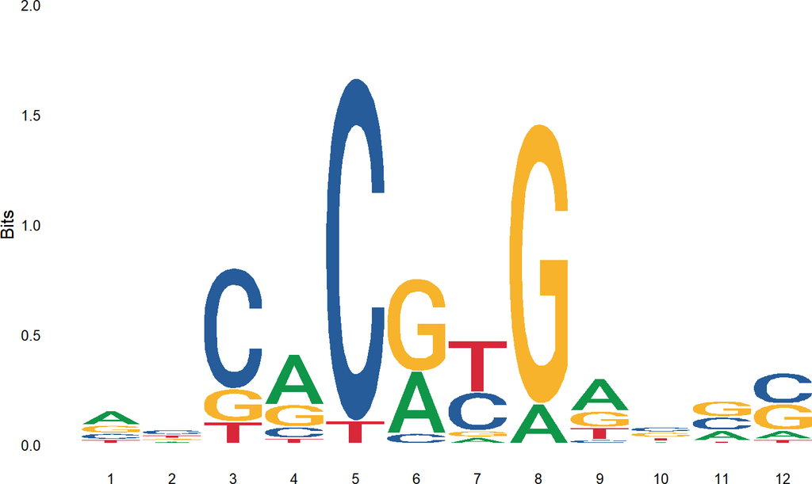

```r
alignindex = 5
print(plot$logo_plot[[alignindex]])
```

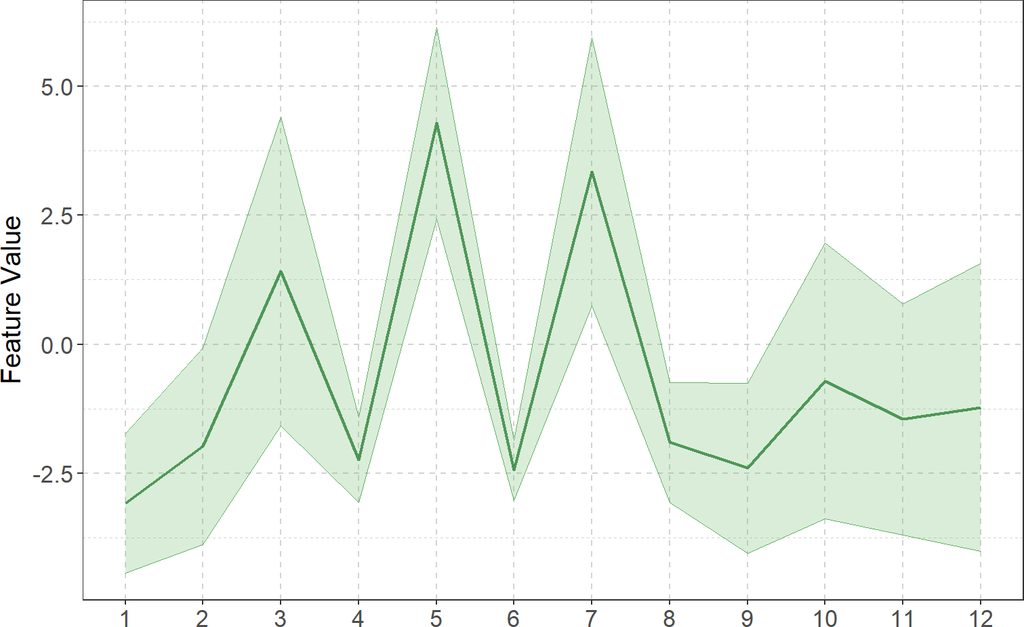

```r
print(plot$area_plot[[alignindex]])
```

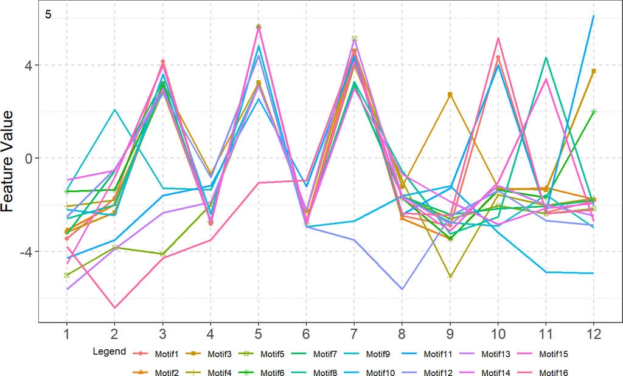

```r
print(plot$line_plot[[alignindex]])
```

#### 4.2.1.7 Use the shape motif visualizer with method ‘distance’

Use `motif_visualizer` with method “distance” for motif alignment and visualization.

```r
motif_data_frame = fasta_input_merge_result$motif_data_frame

motif_shape_data = fasta_input_merge_result$motif_shape_data

motif_vis_dist = motif_visualizer(
  motif_data_frame,
  motif_shape_data,
  motifFrequency = 0.5,
  shapeIndex = 4,
  motifLength = 12,
  align_method = "distance",
  ref_number = 1,
  input_form = 0, ###
  continue_alignment = 1,
  top_motif = 20,
  threshold = 0.6
)
```

The contents of `motif_visualizer` output results.

```r
seq_list_set = motif_vis_dist$align_motif_sequence

align_df = motif_vis_dist$align_motif_dataframe

shape_dfm_set = align_df$motif_shape_df_melt

area_dfm_set = align_df$motif_area_df_melt
```

#### 4.2.1.8 visualize shape motifs

Get the plot of alignment result:

```r
plot = get_plot(shape_dfm_set, area_dfm_set, seq_list_set, shapeIndex = 4)
```

View one of the results of the motif alignment:

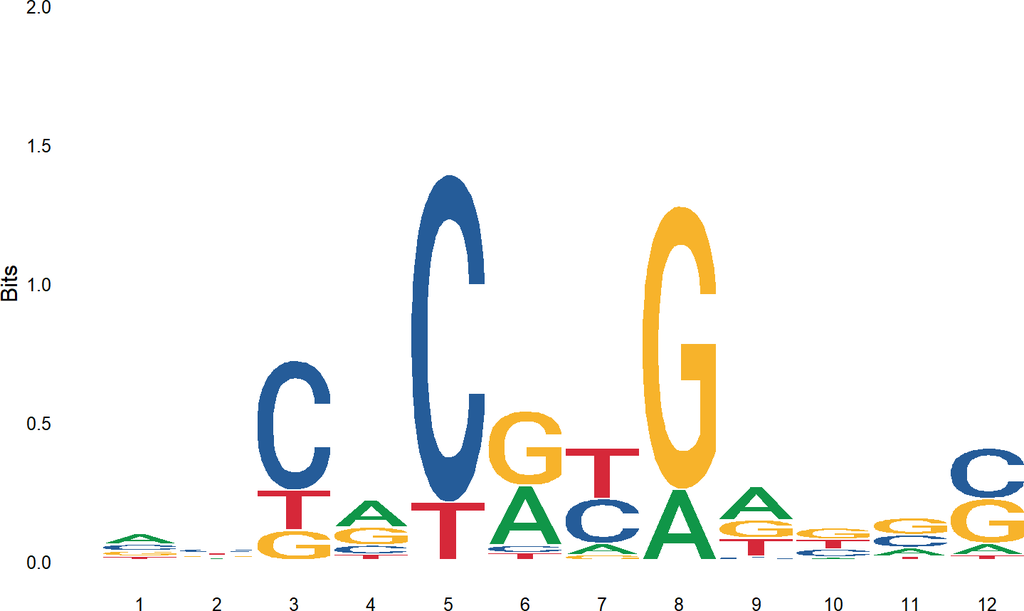

```r
alignindex = 5
print(plot$logo_plot[[alignindex]])
```

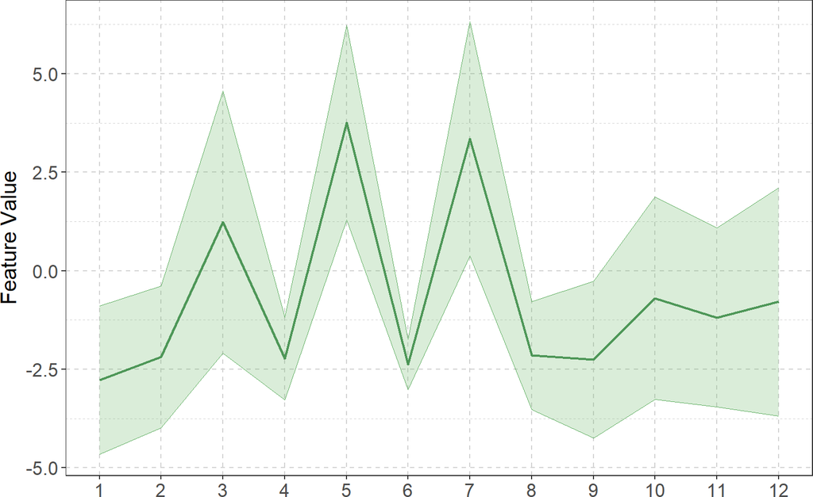

```r
print(plot$area_plot[[alignindex]])
```

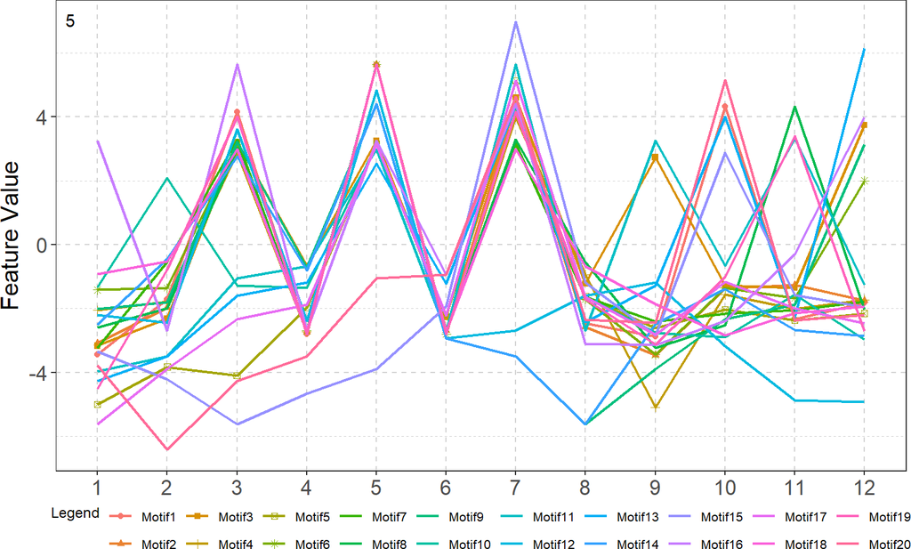

```r
print(plot$line_plot[[alignindex]])
```

### 4.2.2 Single shape feature

To conduct DNA shape motif discovery on single shape feature, the process is similar to the description above. The experimental process will not be described here because we have shown a very detailed process before.

# 5 Reference

3. Lawrence M, Huber W, Pagès H, Aboyoun P, Carlson M, Gentleman R, Morgan M, Carey V (2013). Software for Computing and Annotating Genomic Ranges. *PLoS Computational Biology*, 9. [DOI: 10.1371/journal.pcbi.1003118](https://doi.org/10.1371/journal.pcbi.1003118), [Link to article](http://www.ploscompbiol.org/article/info%3Adoi%2F10.1371%2Fjournal.pcbi.1003118).
4. Chiu T, Comoglio F, Zhou T, Yang L, Paro R, Rohs R (2016). DNAshapeR: an R/Bioconductor package for DNA shape prediction and feature encoding. *Bioinformatics*, 32, 1211-1213. [DOI: 10.1093/bioinformatics/btv735](https://doi.org/10.1093/bioinformatics/btv735).
5. Wagih, Omar. ggseqlogo: a versatile R package for drawing sequence logos. *Bioinformatics* 33, no. 22 (2017): 3645-3647. [DOI: 10.1093/bioinformatics/btx469](https://doi.org/10.1093/bioinformatics/btx469) PMID: 29036507.

# 6 Session Information